```python
# 이름: 김의준 (Euijun Kim)
```

# 1. 문제 정의 및 목표

## 날씨 상태/시간이 판매량에 유의미한 영향을 미치는가? -- 날씨/시간대과 매출관의 관계(날씨/시간대에 따른 매출 변화 예측)

### 예측변수: 판매량

### 설명변수: 그 외

#### 날씨 데이터 변수값 설명:

temp: 기온 dwpt: 이슬점 rhum: 상대습도 prcp: 강수량 wdir: 풍향 wspd: 풍속 pres: 기압

### 자료 출처 kaggle: https://www.kaggle.com/datasets/f02d450f34d1dda2c29da2c31e4650dd98562f4887f4dbb1b7b3cd9ec3348191

```python
# import pandas as pd

# excel_file_path = "Coffee Shop Sales.xlsx"  # 변환할 엑셀 파일 경로
# csv_file_path = "Coffee Shop Sales.csv"      # 저장할 CSV 파일 경로

# df = pd.read_excel(excel_file_path, engine='openpyxl')

# df.to_csv(csv_file_path, index=False, encoding='utf-8')
```

### 이후 또 다른 작업공간을 열어 날씨데이터를 오픈하고 SQL query를 통해 데이터를 조인

### 조인을 완료 했다면 아래로 넘어가기

### 지금 다루는 날씨 데이터는 3개뿐이지만 양이 많아진다면 코드의 가독성을 해치기 때문에 새로운 공간에서 작업함(꼭 그럴필요는 없음).

```python
import numpy as np
import pandas as pd
import seaborn as sns
import matplotlib.pyplot as plt
from matplotlib import rc

from scipy.stats import (
    f_oneway, kruskal, chi2_contingency,
    spearmanr, pearsonr, shapiro,
    boxcox, probplot, kstest
)

from statsmodels.stats.diagnostic import het_breuschpagan
from statsmodels.api import OLS, add_constant
from statsmodels.stats.outliers_influence import variance_inflation_factor

from sklearn.model_selection import (
    train_test_split, cross_val_score, KFold,
    GridSearchCV, ShuffleSplit
)

from sklearn.linear_model import LinearRegression, Ridge
from sklearn.preprocessing import StandardScaler
from sklearn.pipeline import Pipeline
from sklearn.ensemble import RandomForestRegressor

from sklearn.metrics import mean_squared_error, r2_score

import xgboost as xgb



# 조인이 끝난 데이터 불러오기
df = pd.read_csv("coffee_weather_merged.csv", index_col="transaction_id")
df.index.duplicated().any()
df
```

| transaction_id | transaction_date | transaction_time | transaction_qty | store_id | store_location | product_id | unit_price | product_category | product_type | product_detail | ... | HK_pres | HK_coco | LM_temp | LM_dwpt | LM_rhum | LM_prcp | LM_wdir | LM_wspd | LM_pres | LM_coco |
| --- | --- | --- | --- | --- | --- | --- | --- | --- | --- | --- | --- | --- | --- | --- | --- | --- | --- | --- | --- | --- | --- |
| 1 | 2023-01-01 | 07:06:11 | 2 | 5 | Lower Manhattan | 32 | 3.00 | Coffee | Gourmet brewed coffee | Ethiopia Rg | ... | 0.0 | 0 | 9.7 | 9.6 | 99.0 | 0.0 | 220.0 | 11.2 | 1008.0 | 5 |
| 2 | 2023-01-01 | 07:08:56 | 2 | 5 | Lower Manhattan | 57 | 3.10 | Tea | Brewed Chai tea | Spicy Eye Opener Chai Lg | ... | 0.0 | 0 | 9.7 | 9.6 | 99.0 | 0.0 | 220.0 | 11.2 | 1008.0 | 5 |
| 3 | 2023-01-01 | 07:14:04 | 2 | 5 | Lower Manhattan | 59 | 4.50 | Drinking Chocolate | Hot chocolate | Dark chocolate Lg | ... | 0.0 | 0 | 9.7 | 9.6 | 99.0 | 0.0 | 220.0 | 11.2 | 1008.0 | 5 |
| 4 | 2023-01-01 | 07:20:24 | 1 | 5 | Lower Manhattan | 22 | 2.00 | Coffee | Drip coffee | Our Old Time Diner Blend Sm | ... | 0.0 | 0 | 9.7 | 9.6 | 99.0 | 0.0 | 220.0 | 11.2 | 1008.0 | 5 |
| 5 | 2023-01-01 | 07:22:41 | 2 | 5 | Lower Manhattan | 57 | 3.10 | Tea | Brewed Chai tea | Spicy Eye Opener Chai Lg | ... | 0.0 | 0 | 9.7 | 9.6 | 99.0 | 0.0 | 220.0 | 11.2 | 1008.0 | 5 |
| ... | ... | ... | ... | ... | ... | ... | ... | ... | ... | ... | ... | ... | ... | ... | ... | ... | ... | ... | ... | ... | ... |
| 149452 | 2023-06-30 | 20:18:41 | 2 | 8 | Hell's Kitchen | 44 | 2.50 | Tea | Brewed herbal tea | Peppermint Rg | ... | 1018.0 | 5 | 0.0 | 0.0 | 0.0 | 0.0 | 0.0 | 0.0 | 0.0 | 0 |
| 149453 | 2023-06-30 | 20:25:10 | 2 | 8 | Hell's Kitchen | 49 | 3.00 | Tea | Brewed Black tea | English Breakfast Lg | ... | 1018.0 | 5 | 0.0 | 0.0 | 0.0 | 0.0 | 0.0 | 0.0 | 0.0 | 0 |
| 149454 | 2023-06-30 | 20:31:34 | 1 | 8 | Hell's Kitchen | 45 | 3.00 | Tea | Brewed herbal tea | Peppermint Lg | ... | 1018.0 | 5 | 0.0 | 0.0 | 0.0 | 0.0 | 0.0 | 0.0 | 0.0 | 0 |
| 149455 | 2023-06-30 | 20:57:19 | 1 | 8 | Hell's Kitchen | 40 | 3.75 | Coffee | Barista Espresso | Cappuccino | ... | 1018.0 | 5 | 0.0 | 0.0 | 0.0 | 0.0 | 0.0 | 0.0 | 0.0 | 0 |
| 149456 | 2023-06-30 | 20:57:19 | 2 | 8 | Hell's Kitchen | 64 | 0.80 | Flavours | Regular syrup | Hazelnut syrup | ... | 1018.0 | 5 | 0.0 | 0.0 | 0.0 | 0.0 | 0.0 | 0.0 | 0.0 | 0 |

149116 rows × 34 columns

```python
# Left Join으로 데이터셋 하나씩 병합하였고 데이터 정리 필요.

# import numpy as np


weather_cols = ['temp','dwpt','rhum','prcp','wdir','wspd','pres','coco']

for col in weather_cols:
    # 예: col='temp'일 때 AT_temp, HK_temp, LM_temp를 하나로 합쳐 'temp'에 넣는다
    df[col] = np.where(df['store_location'] == 'Astoria',
                       df[f'AT_{col}'],
                       np.where(df['store_location'] == "Hell's Kitchen",
                                df[f'HK_{col}'],
                                df[f'LM_{col}']))

# 합친 뒤에는 'AT_temp', 'HK_temp', 'LM_temp' 식으로 지역별 이니셜이 붙은 원본 컬럼은 지워도 됨
drop_cols = []
for col in weather_cols:
    drop_cols.append(f'AT_{col}')
    drop_cols.append(f'HK_{col}')
    drop_cols.append(f'LM_{col}')

df.drop(columns=drop_cols, inplace=True)
df.sort_values(by="transaction_id", ascending=True, inplace=True)
```

```python
df.to_csv("Final_DF.csv", index=True, encoding='utf-8')  # 분석을 시작하기전 최종 데이터 저장
tempDF= df
```

# 2. 데이터 준비 및 탐색(EDA)

```python
print("데이터 크기 (행, 열):", df.shape)

print("\n컬럼 정보:")
print(df.dtypes)

print("\n결측치 개수:")
print(df.isnull().sum())

# 결측치 없음 확인!

print("\n기본 통계량:")
print(df.describe())
```

```
데이터 크기 (행, 열): (149116, 18)

컬럼 정보:
transaction_date     object
transaction_time     object
transaction_qty       int64
store_id              int64
store_location       object
product_id            int64
unit_price          float64
product_category     object
product_type         object
product_detail       object
temp                float64
dwpt                float64
rhum                float64
prcp                float64
wdir                float64
wspd                float64
pres                float64
coco                  int64
dtype: object

결측치 개수:
transaction_date    0
transaction_time    0
transaction_qty     0
store_id            0
store_location      0
product_id          0
unit_price          0
product_category    0
product_type        0
product_detail      0
temp                0
dwpt                0
rhum                0
prcp                0
wdir                0
wspd                0
```

[output cut: 19 more lines]

```
min       -16.000000     -26.500000      12.000000       0.000000
25%         6.700000      -2.000000      45.000000       0.000000
50%        12.800000       4.500000      60.000000       0.000000
75%        18.300000      10.500000      76.000000       0.000000
max        32.200000      22.100000     100.000000      14.000000

                wdir           wspd           pres           coco
count  149116.000000  149116.000000  149116.000000  149116.000000
mean      164.988874       9.595259    1015.408699       2.990960
std       121.877814       6.523157       8.296276       2.370404
min         0.000000       0.000000     987.400000       1.000000
25%        41.000000       5.400000    1009.300000       1.000000
50%       200.000000       9.400000    1016.100000       3.000000
75%       273.000000      13.000000    1021.900000       3.000000
max       360.000000      54.000000    1039.000000      18.000000
```

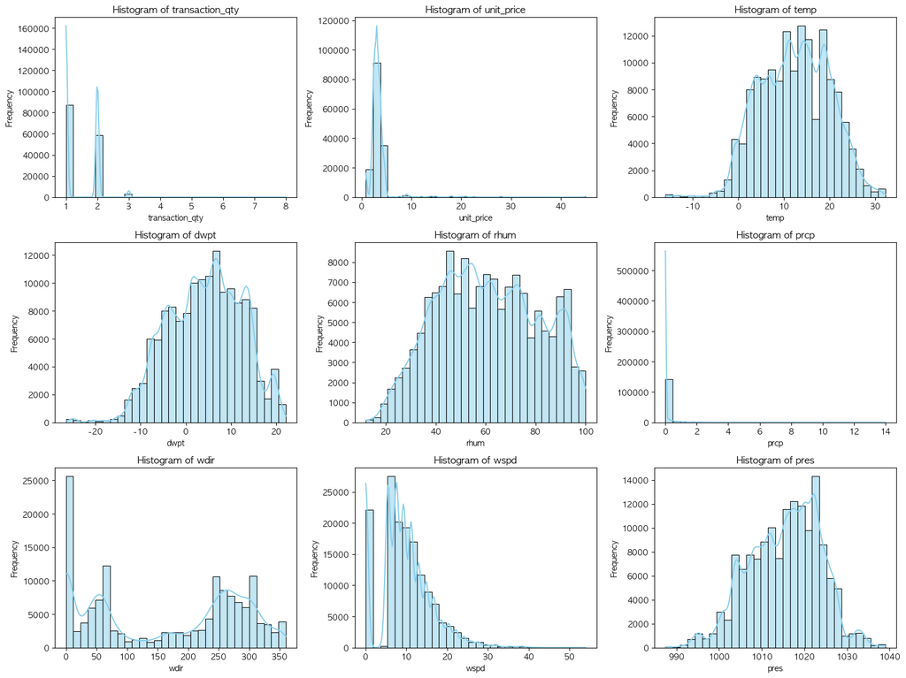

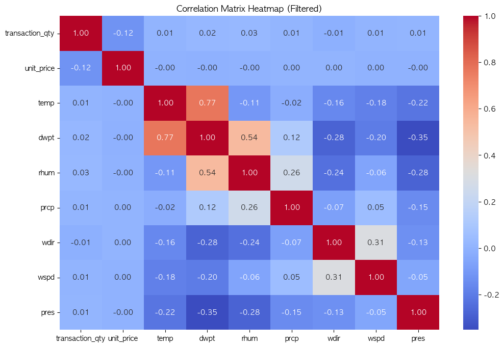

```python
# 상관관계 분석에서 제외할 컬럼 정의
exclude_columns = ['store_id', 'product_id', 'coco']

# 주요 수치형 컬럼 추출 (제외 컬럼 제거)
numeric_columns = [
    col for col in df.select_dtypes(include=['int64', 'float64']).columns
    if col not in exclude_columns
]

# 히스토그램: 3x3 레이아웃으로 배치
num_cols = len(numeric_columns)
cols_per_row = 3  # 열 수를 3으로 고정
rows = (num_cols + cols_per_row - 1) // cols_per_row  # 행 계산

fig, axes = plt.subplots(rows, cols_per_row, figsize=(16, 12))
axes = axes.flatten()

for i, col in enumerate(numeric_columns):
    sns.histplot(df[col], bins=30, kde=True, ax=axes[i], color='skyblue')
    axes[i].set_title(f'Histogram of {col}')
    axes[i].set_xlabel(col)
    axes[i].set_ylabel('Frequency')

# 나머지 빈 서브플롯 숨기기
for j in range(i + 1, len(axes)):
    axes[j].axis('off')

plt.tight_layout()
plt.show()

# 상관 행렬 생성 및 히트맵 시각화 (제외 컬럼 제거 후)
correlation_matrix = df[numeric_columns].corr()
plt.figure(figsize=(12, 8))
sns.heatmap(correlation_matrix, annot=True, fmt=".2f", cmap="coolwarm", cbar=True)
plt.title("Correlation Matrix Heatmap (Filtered)")
plt.show()
```

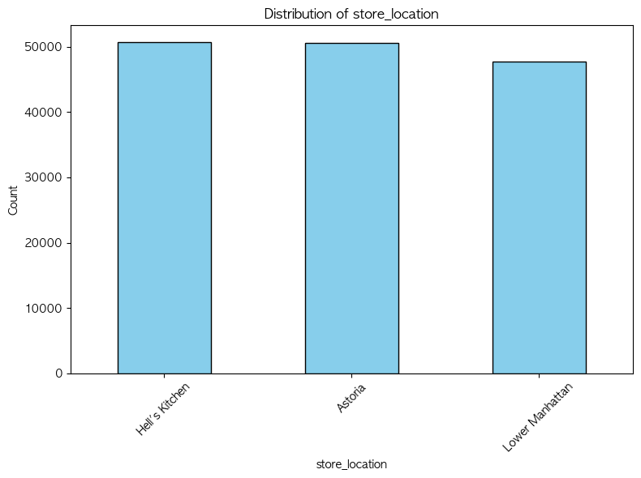

```python
# 사실 범주형 데이터에서 막대그래프로 시각화할 의미있는 컬럼은 딱히 없음.

# 범주형 데이터에서 제외할 컬럼 정의
exclude_categorical_columns = ['transaction_date', 'transaction_time', 'product_detail', 'product_type','product_category']

# 범주형 컬럼 추출 (제외 컬럼 제거)
categorical_columns = [
    col for col in df.select_dtypes(include=['object']).columns
    if col not in exclude_categorical_columns
]

num_cat_cols = len(categorical_columns)

# 한 행에 배치
fig, axes = plt.subplots(1, num_cat_cols, figsize=(8 * num_cat_cols, 6))
axes = axes.flatten() if num_cat_cols > 1 else [axes]

for i, col in enumerate(categorical_columns):
    value_counts = df[col].value_counts()
    value_counts.plot(kind='bar', ax=axes[i], color='skyblue', edgecolor='k')
    axes[i].set_title(f'Distribution of {col}')
    axes[i].set_xlabel(col)
    axes[i].set_ylabel('Count')
    axes[i].tick_params(axis='x', rotation=45)

plt.tight_layout()
plt.show()
```

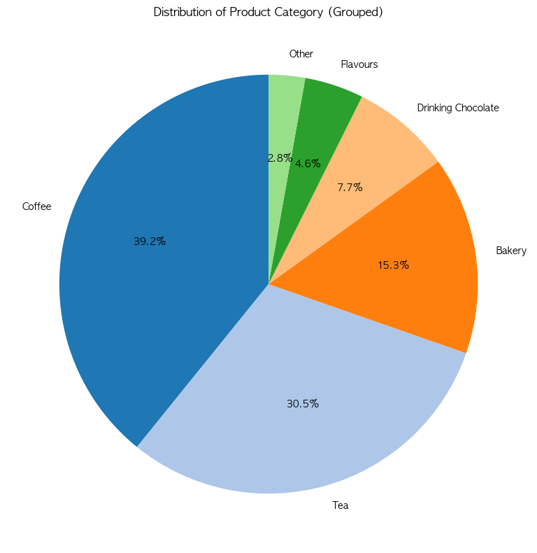

```python
# 'product_category' 컬럼의 고유값 개수 계산
product_category_counts = df['product_category'].value_counts()

# 빈도 상위 항목과 기타로 묶기
threshold = 0.02  # 비율 기준: 2% 미만 항목은 '기타 등등'으로 묶음
total = product_category_counts.sum()
product_category_counts_filtered = product_category_counts[product_category_counts / total >= threshold]
other_count = product_category_counts[product_category_counts / total < threshold].sum()

# "기타 등등" 추가
product_category_counts_filtered['Other'] = other_count

# 원형 그래프 생성
plt.figure(figsize=(8, 8))
plt.pie(
    product_category_counts_filtered,
    labels=product_category_counts_filtered.index,
    autopct='%1.1f%%',  # 퍼센티지 표시
    startangle=90,      # 시작 각도 설정
    colors=plt.cm.tab20.colors  # 색상 팔레트 설정
)
plt.title('Distribution of Product Category (Grouped)')
plt.tight_layout()
plt.show()
```

```python
# 기타 등등에 포함된 항목 출력
other_items = product_category_counts[product_category_counts / total < threshold]

print("그 외의 것들 세부내용':")
for item, count in other_items.items():
    print(f"- {item}: {count} ({(count / total) * 100:.1f}%)")
```

```
그 외의 것들 세부내용':
- Coffee beans: 1753 (1.2%)
- Loose Tea: 1210 (0.8%)
- Branded: 747 (0.5%)
- Packaged Chocolate: 487 (0.3%)
```

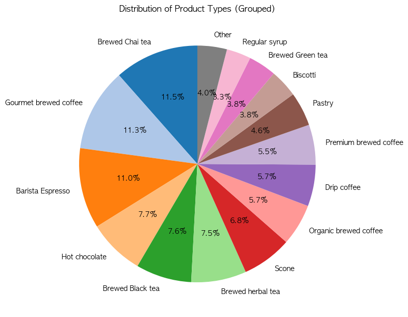

```python
# import pandas as pd
# import matplotlib.pyplot as plt

# 'product_type' 컬럼의 고유값 개수 계산
product_type_counts = df['product_type'].value_counts()

# 빈도 상위 항목과 기타로 묶기
threshold = 0.02  # 비율 기준: 2% 미만 항목은 '기타 등등'으로 묶음
total = product_type_counts.sum()
product_type_counts_filtered = product_type_counts[product_type_counts / total >= threshold]
other_count = product_type_counts[product_type_counts / total < threshold].sum()

# "기타 등등" 추가
product_type_counts_filtered['Other'] = other_count

# 원형 그래프 생성
plt.figure(figsize=(8, 8))
plt.pie(
    product_type_counts_filtered,
    labels=product_type_counts_filtered.index,
    autopct='%1.1f%%',  # 퍼센티지 표시
    startangle=90,      # 시작 각도 설정
    colors=plt.cm.tab20.colors  # 색상 팔레트 설정
)
plt.title('Distribution of Product Types (Grouped)')
plt.tight_layout()
plt.show()
```

```python
# 기타 등등에 포함된 항목 출력
other_items = product_type_counts[product_type_counts / total < threshold]

print("그 외의 것들 세부내용':")
for item, count in other_items.items():
    print(f"- {item}: {count} ({(count / total) * 100:.2f}%)")
```

```
그 외의 것들 세부내용':
- Sugar free syrup: 1811 (1.21%)
- Housewares: 526 (0.35%)
- Chai tea: 443 (0.30%)
- Organic Beans: 415 (0.28%)
- Gourmet Beans: 366 (0.25%)
- Premium Beans: 336 (0.23%)
- Espresso Beans: 319 (0.21%)
- Herbal tea: 305 (0.20%)
- Black tea: 303 (0.20%)
- Drinking Chocolate: 266 (0.18%)
- Organic Chocolate: 221 (0.15%)
- Clothing: 221 (0.15%)
- House blend Beans: 183 (0.12%)
- Green tea: 159 (0.11%)
- Green beans: 134 (0.09%)
```

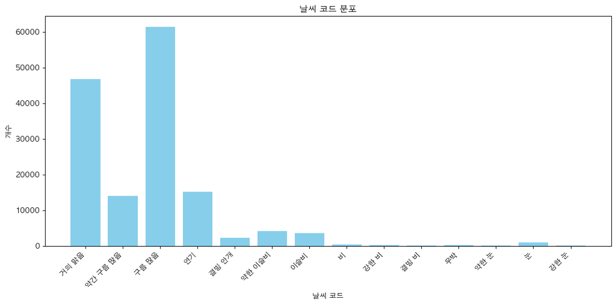

```python
### 컬럼 중 coco 는 Weather Condition Codes 를 나타냄

# import matplotlib.pyplot as plt
# from matplotlib import rc

rc('font', family='AppleGothic')
plt.rcParams['axes.unicode_minus'] = False  # 마이너스 기호 깨짐 방지

# coco 코드와 의미를 매핑
coco_labels = {
    0: "맑음", 1: "거의 맑음", 2: "약간 구름 많음", 3: "구름 많음", 4: "흐림",
    5: "연기", 6: "안개", 7: "결빙 안개", 8: "약한 이슬비", 9: "이슬비",
    10: "결빙 이슬비", 11: "약한 비", 12: "비", 13: "강한 비", 14: "결빙 비",
    15: "우박", 16: "약한 눈", 17: "눈", 18: "강한 눈", 19: "진눈깨비",
    20: "우박성 진눈깨비", 21: "천둥", 22: "비를 동반한 천둥", 23: "눈을 동반한 천둥"
}

# coco 값별 개수 집계 (값이 0인 상태 제거)
coco_counts = df['coco'].value_counts().sort_index()
coco_counts = coco_counts[coco_counts > 0]

# 막대 그래프 그리기
plt.figure(figsize=(12, 6))
plt.bar(coco_counts.index.map(coco_labels), coco_counts.values, color='skyblue')
plt.xticks(rotation=45, ha='right')  # 레이블 기울이기
plt.xlabel('날씨 코드')
plt.ylabel('개수')
plt.title('날씨 코드 분포')
plt.tight_layout()  # 레이아웃 조정
plt.show()
```

### 결측치는 앞전 단계에서 0임을 확인.

### 필요 없는 컬럼 제거

```python
columns_to_drop = ['store_id', 'product_id']
# store_id는 location으로 대체가 가능하고, product_id는 product_category와 product_type으로 대체가능 하기 때문에 삭제.
df.drop(columns=columns_to_drop, inplace=True)
```

### 데이터 변환

```python
temp = df
# 날짜 데이터를 datetime 형식으로 변환
temp['transaction_date'] = pd.to_datetime(temp['transaction_date'])

# 날짜 관련 변환
temp['month'] = temp['transaction_date'].dt.month  # 월
temp['weekday'] = temp['transaction_date'].dt.day_name()  # 요일

# 시간대 범주화
def categorize_time(time_str):
    hour = int(time_str.split(':')[0])
    if 5 <= hour < 11:
        return '아침'
    elif 11 <= hour < 17:
        return '점심'
    elif 17 <= hour < 21:
        return '저녁'
    else:
        return '밤'

temp['time_of_day'] = temp['transaction_time'].apply(categorize_time)

# 날씨 그룹화
def categorize_weather(coco):
    if coco in [0, 1, 2, 3]:
        return '맑음'
    elif coco in [4, 5, 6, 7]:
        return '흐림'
    elif coco in [8, 9, 10, 11, 12, 13, 14]:
        return '비'
    elif coco in [16, 17, 18, 19]:
        return '눈'
    elif coco in [15, 20, 21, 22, 23]:
        return '격렬한 날씨'
    else:
        return 'Other'

temp['weather_group'] = temp['coco'].apply(categorize_weather)

# 매출 계산
temp['sales'] = temp['transaction_qty'] * temp['unit_price']
#coco는 새컬럼을 생성했기 때문에 삭제
temp = temp.drop(columns=['coco'], errors='ignore')
#wdir 은 수치형 밸류로 의미를 가지지 않기 때문에 삭제
temp = temp.drop(columns=['wdir'], errors='ignore')



# 결과 확인
temp.head()
data = temp
```

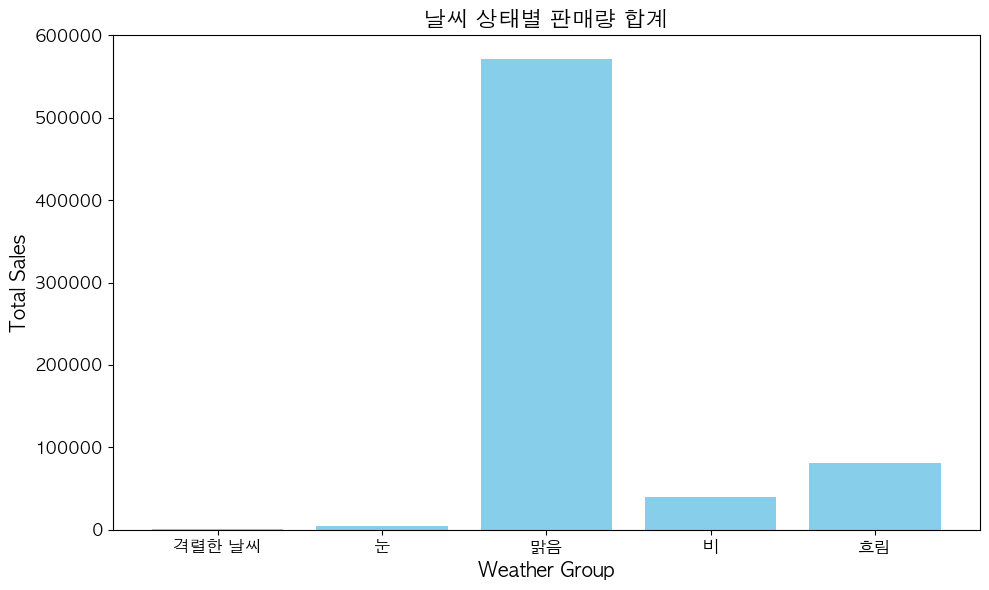

```python
# 날씨 상태별 판매량 합계 계산
weather_sales = temp.groupby('weather_group')['sales'].sum().reset_index()

# 막대 그래프 생성
plt.figure(figsize=(10, 6))
plt.bar(weather_sales['weather_group'], weather_sales['sales'], color='skyblue')

# 그래프 꾸미기
plt.title('날씨 상태별 판매량 합계', fontsize=16)
plt.xlabel('Weather Group', fontsize=14)
plt.ylabel('Total Sales', fontsize=14)
plt.xticks(fontsize=12)
plt.yticks(fontsize=12)
plt.tight_layout()

# 그래프 표시
plt.show()
```

```python
temp.to_csv("Final_DF_forTest.csv", index=True, encoding='utf-8')
```

### 예측 모델을 위한 예측변수 설정

### 거래 하나하나를 예측변수로 삼는것은 사실상 불가능(개인의 거래는 개인의 취향에 너무 많이 바뀌기 때문, 일단위 혹은 조금 더 세분화한 하루의(아침,점심,저녁) 기준으로 총 매출 컬럼을 생성하는게 더 나아 보임.

```python
# Convert sales column to numeric for aggregation
data['sales'] = pd.to_numeric(data['sales'], errors='coerce')

# Group data by transaction_date, store_location, and time_of_day, and calculate the sum of sales and transaction_qty
grouped_sales = data.groupby(['transaction_date', 'store_location', 'time_of_day']).agg(
    {'sales': 'sum', 'transaction_qty': 'sum'}
).reset_index()

# Calculate the mean for weather-related columns
weather_columns = ['temp', 'dwpt', 'rhum', 'prcp', 'wspd', 'pres']
mean_weather = data.groupby(['transaction_date', 'store_location', 'time_of_day'])[weather_columns].mean().reset_index()

# Round all weather-related columns to 2 decimal places
mean_weather[weather_columns] = mean_weather[weather_columns].round(2)

# Process weather_group column to find the most frequent value with '주로' prefix
weather_group = data.groupby(['transaction_date', 'store_location', 'time_of_day'])['weather_group'].agg(
    lambda x: f"주로 {x.mode()[0]}" if len(x.mode()) == 1 else '복합적'
).reset_index()

# Merge sales, transaction_qty, mean weather, and weather group data together
final_result = pd.merge(grouped_sales, mean_weather, on=['transaction_date', 'store_location', 'time_of_day'])
final_result = pd.merge(final_result, weather_group, on=['transaction_date', 'store_location', 'time_of_day'])

# Retain additional columns like month, weekday, etc.
additional_columns = ['month', 'weekday']
additional_data = data.groupby(['transaction_date', 'store_location', 'time_of_day'])[additional_columns].first().reset_index()

# Merge with the final dataset
final_result = pd.merge(final_result, additional_data, on=['transaction_date', 'store_location', 'time_of_day'])

# Drop 'coco' column if it exists
final_result = final_result.drop(columns=['coco'], errors='ignore')
final_result.to_csv("Final_DF_forTest_for_Test.csv", index=True, encoding='utf-8')

복합적_count = final_result['weather_group'].value_counts().get('복합적', 0)
밤_count = df['time_of_day'].value_counts().get('밤', 0)

print(f"'복합적'의 개수: {복합적_count}")
print(f"'밤'의 개수: {밤_count}")
```

```
'복합적'의 개수: 5
'밤'의 개수: 0
```

# 3. 몇가지 가설 설정

시간(transaction_time)에 따라 구매량(transaction_qty)의 패턴이 존재하는가? 예시 가설: 아침에는 커피와 같은 카페인 음료가, 오후나 저녁에는 디저트 음료가 더 많이 팔린다. 온도와 구매 패턴? 예시 가설: 특정 시간대(transaction_time)에 판매량이 더 높을 것이다. 지역(store_location)에 따라 특정 제품군의 구매 패턴이 달라지는가? 예시 가설: 지역별 소비 취향 차이가 있을 것이다. 날씨와 판매량 패턴? 예시 가설: 날씨(coco)가 특정 상품(product_category, product_type) 선호도에 영향을 미친다. 예시 가설: 특정 날씨 조건(temp, prcp, coco)에서 판매량(transaction_qty)이 증가하거나 감소할 것이다.

### 아쉬운 점: iced인지 hot 인지에 대한 정보 X.

## 3.1 시간에 따른 구매량의 패턴 가설 검정

### 시간대에 따라 구매자들의 소비 패턴이 달라지는가?

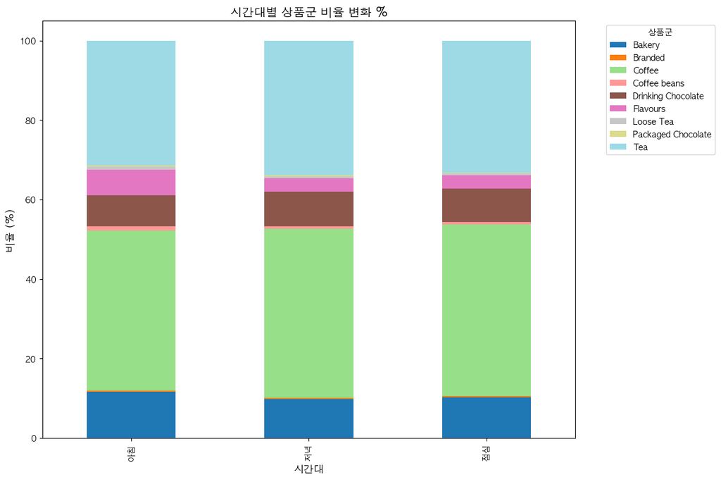

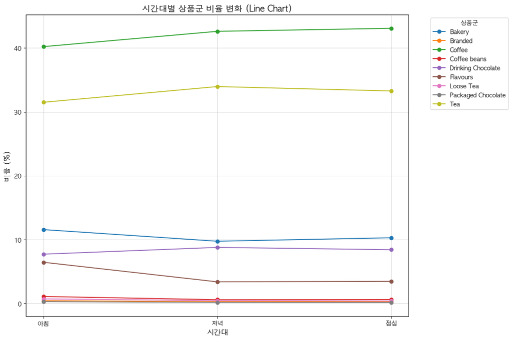

```
# Chi-square 검정 결과:
Chi2 Statistic: 1613.4446182504541
p-value: 0.0
```

```python
# import pandas as pd
# import numpy as np
# from scipy.stats import f_oneway, kruskal
# import matplotlib.pyplot as plt
# import seaborn as sns
# import numpy as np
# from scipy.stats import chi2_contingency

data = temp

# 상품군별 시간대별 구매량 그룹화
grouped = data.groupby(['time_of_day', 'product_category'])['transaction_qty'].sum().reset_index()
grouped_pivot = grouped.pivot(index='product_category', columns='time_of_day', values='transaction_qty').fillna(0)

# 시간대별 비율 계산
grouped_percentage = grouped_pivot.div(grouped_pivot.sum(axis=0), axis=1) * 100

# Chi-square 독립성 검정 수행 (원본 데이터 사용)
chi2, p, dof, expected = chi2_contingency(grouped_pivot)

# 기대 빈도와 관찰 빈도의 차이 계산
difference = grouped_pivot - expected

# 시각화: 시간대별 상품군 비율 변화 (100% Stacked Bar Chart)
grouped_percentage.T.plot(kind='bar', stacked=True, figsize=(12, 8), colormap='tab20')
plt.title('시간대별 상품군 비율 변화 %', fontsize=14)
plt.xlabel('시간대', fontsize=12)
plt.ylabel('비율 (%)', fontsize=12)
plt.legend(title='상품군', bbox_to_anchor=(1.05, 1), loc='upper left')
plt.tight_layout()
plt.show()

# 시각화: 상품군 비율의 변화 추이를 Line Chart로 표시
plt.figure(figsize=(12, 8))
for product in grouped_percentage.index:
    plt.plot(grouped_percentage.columns, grouped_percentage.loc[product], marker='o', label=product)

plt.title('시간대별 상품군 비율 변화 (Line Chart)', fontsize=14)
plt.xlabel('시간대', fontsize=12)
plt.ylabel('비율 (%)', fontsize=12)
plt.legend(title='상품군', fontsize=10, bbox_to_anchor=(1.05, 1), loc='upper left')
plt.grid(alpha=0.5)
plt.tight_layout()
plt.show()

# 결과 출력
print("# Chi-square 검정 결과:")
print(f"Chi2 Statistic: {chi2}")
print(f"p-value: {p}")
```

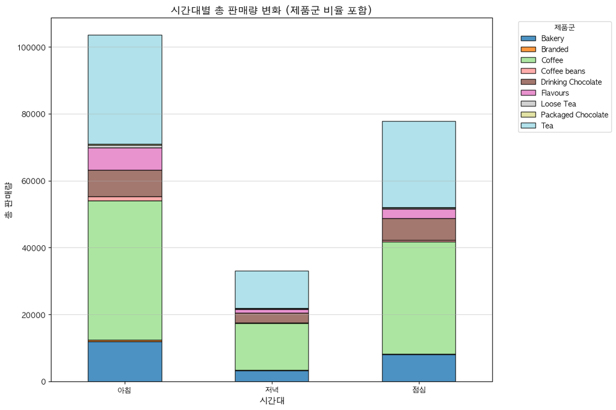

```python
# 시간대별 총 판매량 계산
time_total_sales = grouped_pivot.sum(axis=0)

# 상품군별 시간대별 총 판매량 재계산
time_grouped_sales = grouped_pivot.T

# 시각화: 시간대별 총 판매량 변화 (Stacked Bar Chart with Product Categories)
plt.figure(figsize=(12, 8))
time_grouped_sales.plot(kind='bar', stacked=True, figsize=(12, 8), colormap='tab20', alpha=0.8, edgecolor='black')

plt.title('시간대별 총 판매량 변화 (제품군 비율 포함)', fontsize=14)
plt.xlabel('시간대', fontsize=12)
plt.ylabel('총 판매량', fontsize=12)
plt.xticks(rotation=0)
plt.legend(title='제품군', bbox_to_anchor=(1.05, 1), loc='upper left')
plt.grid(axis='y', alpha=0.5)
plt.tight_layout()
plt.show()
```

### Chi-square를 이용해 두 범주형 변수(시간대와 상품군)가 서로 독립적인지(즉, 비율이 시간대에 따라 변하지 않는지) 평가.

### Chi-square 독립성 검정은 두 범주형 변수 간의 연관성을 검정하는 데 사용되며, 현재 가설 검정의 목적에 부합.

### 결과 해석:

### 시각화에서 변화가 눈에 띄지 않았음. 유의미한 차이가 없어 보임.

### 그러나 Chi-square 결과는 유의미한 차이가 있다고 판단 -> 이는 검증의 결과가 작은 변화도 민감하게 검출해서아 아닌가 함.

#### 아침, 점심, 저녁의 상품군 선호도가 미세하게 변하고 있는것은 사실이나 그 비율이 크지 않은것도 사실.

### 결론: 시간대별의 구분(아침,점심,저녁)은 예측 모델 생성이 의미있는 feature가 될 가능성이 있어 보임.

## 3.2 온도와 구매 패턴

### 온도에 따라 판매량의 차이가 있는가?

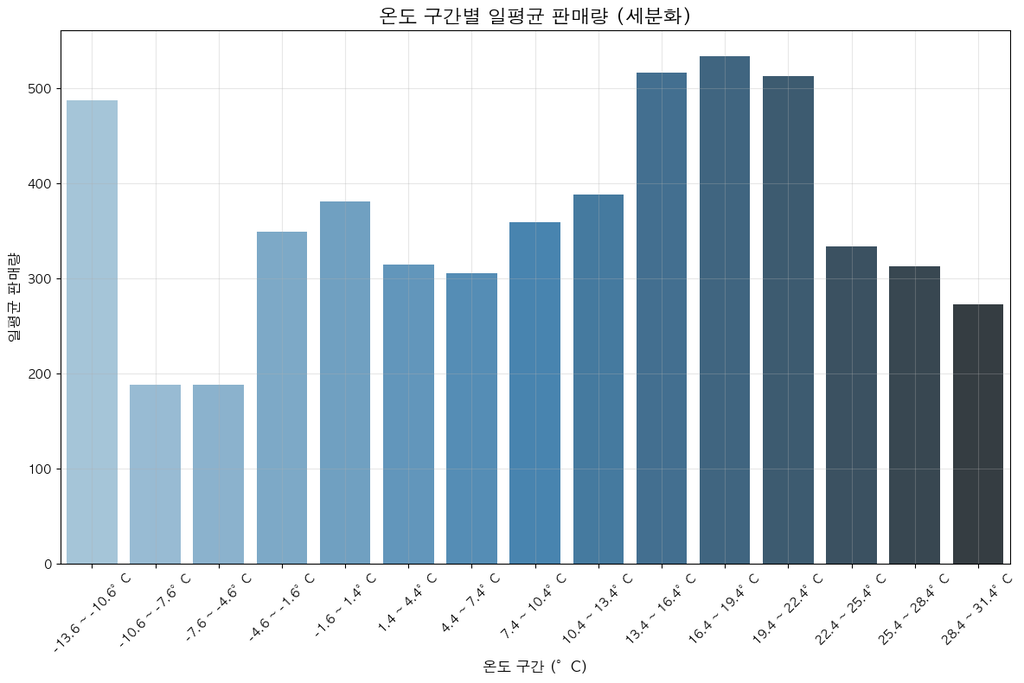

```
# Shapiro-Wilk Test 결과 (일평균 판매량 기준)
Shapiro-Wilk 통계량: 0.9303, p-value: 0.2759
# 상관분석 결과 (온도 구간별 일평균 판매량 기준, Pearson)
Pearson 상관계수: 0.20148136318053766, p-value: 0.47147983478010463
```

```python
data = temp

# 1) 일자와 시간대를 기준으로 평균 기온/총 판매량 집계
daily_time_period_data = data.groupby(['transaction_date', 'time_of_day']).agg(
    avg_temp=('temp', 'mean'),
    total_qty=('transaction_qty', 'sum')
).reset_index()

# 2) 온도를 일정 간격으로 구간화 (step=3°C)
step = 3
temp_min = daily_time_period_data['avg_temp'].min()
temp_max = daily_time_period_data['avg_temp'].max()

daily_time_period_data['temp_bin'] = pd.cut(
    daily_time_period_data['avg_temp'],
    bins=np.arange(temp_min, temp_max + step, step)
)

# 3) 온도 구간별로 '합계' 대신 '평균 판매량'을 계산
binned_data = daily_time_period_data.groupby('temp_bin').agg(
    avg_temp=('avg_temp', 'mean'),              # 구간 내 평균 기온
    avg_qty=('total_qty', 'mean')               # 구간 내 '일평균 판매량'
).reset_index()

# 4) 시각화용 레이블(예: "0.0 ~ 3.0°C") 생성
binned_data['temp_bin_label'] = binned_data['temp_bin'].apply(
    lambda x: f"{x.left:.1f} ~ {x.right:.1f}°C"
)

# 5) 그래프 시각화: y축을 'avg_qty' (일평균 판매량)으로 변경
plt.figure(figsize=(12, 8))
sns.barplot(
    x='temp_bin_label',
    y='avg_qty',
    data=binned_data,
    palette='Blues_d'
)
plt.title('온도 구간별 일평균 판매량 (세분화)', fontsize=16)
plt.xlabel('온도 구간 (°C)', fontsize=12)
plt.ylabel('일평균 판매량', fontsize=12)
plt.xticks(rotation=45)
plt.grid(alpha=0.3)
plt.tight_layout()
plt.show()

shapiro_stat, shapiro_p = shapiro(binned_data['avg_qty'])
print("# Shapiro-Wilk Test 결과 (일평균 판매량 기준)")
print(f"Shapiro-Wilk 통계량: {shapiro_stat:.4f}, p-value: {shapiro_p:.4f}")

pearson_corr, pearson_p = pearsonr(binned_data['avg_temp'], binned_data['avg_qty'])
print("# 상관분석 결과 (온도 구간별 일평균 판매량 기준, Pearson)")
print(f"Pearson 상관계수: {pearson_corr}, p-value: {pearson_p}")
```

## 3.3 지역에 따른 제품군의 판매 패턴

### 지역에 따라 제품군의 판매 패턴이 달라 지는가?

```
# 카이제곱 독립성 검정 결과
Chi2 통계량: 1313.5781
p-value: 0.0000
자유도: 16
지역(store_location)에 따라 제품군(product_category)의 구매 패턴에 통계적으로 유의미한 차이가 있습니다.
```

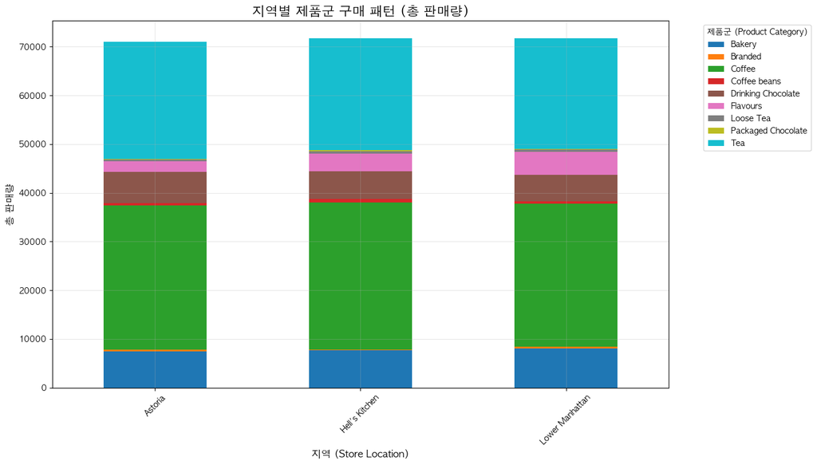

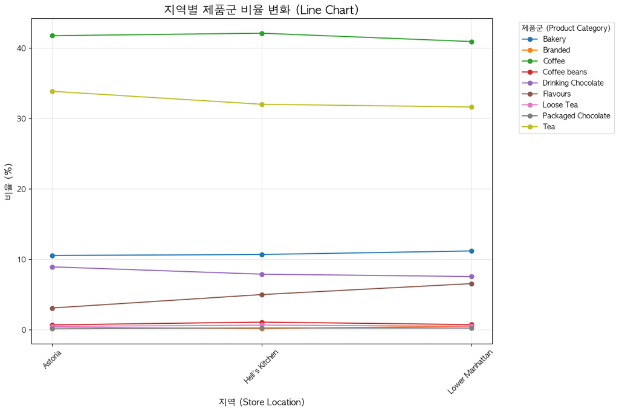

```python
# 지역별 특정 제품군 구매 패턴 분석
# 데이터 전처리: 지역별, 제품군별 총 판매량 계산
data=temp
location_product_data = data.groupby(['store_location', 'product_category']).agg(
    total_qty=('transaction_qty', 'sum')
).reset_index()

# 교차표 생성
contingency_table = pd.pivot_table(
    location_product_data,
    values='total_qty',
    index='store_location',
    columns='product_category',
    aggfunc='sum',
    fill_value=0
)

# 카이제곱 독립성 검정
chi2_stat, chi2_p, chi2_dof, chi2_expected = chi2_contingency(contingency_table)

print("# 카이제곱 독립성 검정 결과")
print(f"Chi2 통계량: {chi2_stat:.4f}")
print(f"p-value: {chi2_p:.4f}")
print(f"자유도: {chi2_dof}")

if chi2_p < 0.05:
    print("지역(store_location)에 따라 제품군(product_category)의 구매 패턴에 통계적으로 유의미한 차이가 있습니다.")
else:
    print("지역(store_location)에 따른 제품군(product_category)의 구매 패턴에 통계적으로 유의미한 차이가 없습니다.")

# 시각화: 지역별 제품군 구매 패턴 (총 판매량)
plt.figure(figsize=(12, 8))
contingency_table.plot(kind='bar', stacked=True, figsize=(14, 8), cmap='tab10')
plt.title('지역별 제품군 구매 패턴 (총 판매량)', fontsize=16)
plt.xlabel('지역 (Store Location)', fontsize=12)
plt.ylabel('총 판매량', fontsize=12)
plt.xticks(rotation=45)
plt.legend(title='제품군 (Product Category)', bbox_to_anchor=(1.05, 1), loc='upper left')
plt.tight_layout()
plt.grid(alpha=0.3)
plt.show()

contingency_table_percentage = contingency_table.div(contingency_table.sum(axis=1), axis=0) * 100


# 시각화: 지역별 제품군 비율 변화 (Line Chart)
plt.figure(figsize=(12, 8))
for product in contingency_table_percentage.columns:
    plt.plot(contingency_table_percentage.index, contingency_table_percentage[product], marker='o', label=product)
plt.title('지역별 제품군 비율 변화 (Line Chart)', fontsize=16)
plt.xlabel('지역 (Store Location)', fontsize=12)
plt.ylabel('비율 (%)', fontsize=12)
plt.xticks(rotation=45)
plt.legend(title='제품군 (Product Category)', bbox_to_anchor=(1.05, 1), loc='upper left')
plt.tight_layout()
plt.grid(alpha=0.3)
plt.show()

# Kruskal-Wallis 검정 (지역별 특정 제품군 판매량 차이)
kruskal_results = []
for product in location_product_data['product_category'].unique():
    groups = [
        location_product_data[(location_product_data['store_location'] == loc) & (location_product_data['product_category'] == product)]['total_qty']
        for loc in location_product_data['store_location'].unique()
    ]
    kruskal_stat, kruskal_p = kruskal(*groups)
    kruskal_results.append((product, kruskal_stat, kruskal_p))
```

### 결과 해석:

앞선 3.1가설과 상당히 비슷한 형태 -> 시간대와 판매량 사이의 패턴에서도 보았듯이, 숫자는 유의미한 차이가 있다고 보지만 직관적인 차이는 미세해 보임.

예측모델을 위한 변수로서 가능성이 있을 수 있음.

## 3.4 날씨 조건과 수익의 패턴

### 날씨 조건에 따라 수익이 달라지는가?

```
# Spearman 상관 분석 결과 (날씨 변수와 총 매출)
변수: prcp, Spearman 상관계수: -0.0401, p-value: 0.5918
변수: dwpt, Spearman 상관계수: 0.6050, p-value: 0.0000
변수: rhum, Spearman 상관계수: -0.0384, p-value: 0.6075
변수: wspd, Spearman 상관계수: -0.2781, p-value: 0.0002
변수: pres, Spearman 상관계수: -0.1408, p-value: 0.0587
# Kruskal-Wallis 검정 결과 (날씨 변수와 총 매출)
날씨 변수: prcp, Kruskal-Wallis 결과를 계산할 데이터가 부족합니다.
날씨 변수: dwpt, Kruskal-Wallis 통계량: 68.1456, p-value: 0.0000
-> 날씨 변수 'dwpt'이(가) 총 매출에 유의미한 영향을 미칩니다.
날씨 변수: rhum, Kruskal-Wallis 통계량: 15.0670, p-value: 0.3032
날씨 변수: wspd, Kruskal-Wallis 통계량: 10.0575, p-value: 0.0181
-> 날씨 변수 'wspd'이(가) 총 매출에 유의미한 영향을 미칩니다.
날씨 변수: pres, Kruskal-Wallis 통계량: 7.2927, p-value: 0.3991
```

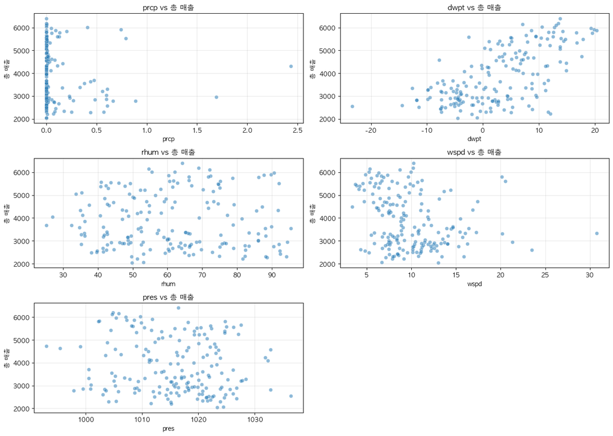

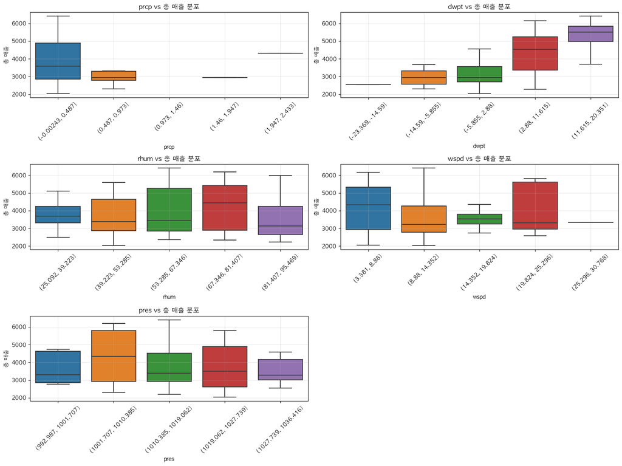

```python
data = temp
# 일별 총 매출과 날씨 데이터 집계
daily_weather_data = data.groupby('transaction_date').agg(
    total_sales=('sales', 'sum'),
    prcp=('prcp', 'mean'),
    dwpt=('dwpt', 'mean'),
    rhum=('rhum', 'mean'),
    wspd=('wspd', 'mean'),
    pres=('pres', 'mean')
).reset_index()

# 1. 각 날씨 변수와 총 매출 간의 상관 분석 (Spearman)
weather_vars = ['prcp', 'dwpt', 'rhum', 'wspd', 'pres']
spearman_results = {}
for var in weather_vars:
    spearman_corr, spearman_p = spearmanr(daily_weather_data[var], daily_weather_data['total_sales'])
    spearman_results[var] = (spearman_corr, spearman_p)

print("# Spearman 상관 분석 결과 (날씨 변수와 총 매출)")
for var, (corr, p) in spearman_results.items():
    print(f"변수: {var}, Spearman 상관계수: {corr:.4f}, p-value: {p:.4f}")

# 2. 특정 날씨 조건에 따른 총 매출 차이 분석 (Kruskal-Wallis 검정)
kruskal_results = []
for var in weather_vars:
    groups = [
        daily_weather_data[(daily_weather_data[var] >= bin_start) & (daily_weather_data[var] < bin_start + 5)]['total_sales']
        for bin_start in np.arange(daily_weather_data[var].min(), daily_weather_data[var].max(), 5)
    ]
    groups = [group for group in groups if len(group) > 1]  # 데이터가 2개 이상인 그룹만 사용
    if len(groups) > 1:
        kruskal_stat, kruskal_p = kruskal(*groups)
        kruskal_results.append((var, kruskal_stat, kruskal_p))
    else:
        kruskal_results.append((var, np.nan, np.nan))  # 그룹이 충분하지 않으면 NaN 추가

print("# Kruskal-Wallis 검정 결과 (날씨 변수와 총 매출)")
for var, stat, p in kruskal_results:
    if not np.isnan(stat):
        print(f"날씨 변수: {var}, Kruskal-Wallis 통계량: {stat:.4f}, p-value: {p:.4f}")
        if p < 0.05:
            print(f"-> 날씨 변수 '{var}'이(가) 총 매출에 유의미한 영향을 미칩니다.")
    else:
        print(f"날씨 변수: {var}, Kruskal-Wallis 결과를 계산할 데이터가 부족합니다.")

# 3. 시각화: 날씨 변수와 총 매출 간의 관계 (Scatter Plot)
plt.figure(figsize=(14, 10))
for i, var in enumerate(weather_vars, 1):
    plt.subplot(3, 2, i)
    sns.scatterplot(x=daily_weather_data[var], y=daily_weather_data['total_sales'], alpha=0.5)
    plt.title(f"{var} vs 총 매출", fontsize=12)
    plt.xlabel(var)
    plt.ylabel("총 매출")
    plt.grid(alpha=0.3)
plt.tight_layout()
plt.show()

# 4. 시각화: 날씨 변수와 총 매출 분포 (Box Plot)
plt.figure(figsize=(16, 12))
for i, var in enumerate(weather_vars, 1):
    plt.subplot(3, 2, i)
    sns.boxplot(x=pd.cut(daily_weather_data[var], bins=5), y=daily_weather_data['total_sales'], showfliers=False)
    plt.title(f"{var} vs 총 매출 분포", fontsize=12)
    plt.xlabel(var)
    plt.ylabel("총 매출")
    plt.xticks(rotation=45)
    plt.grid(alpha=0.3)
plt.tight_layout()
plt.show()
```

- Spearman 상관 분석을 사용한 이유 데이터 특성에 적합:

날씨 변수(prcp, dwpt, rhum, wspd, pres)와 총 매출(sales)은 연속형 데이터로, 두 변수 간의 상관관계를 분석하는 데 적합합니다. 날씨와 매출 간의 관계는 선형일 수도 있고, 비선형일 수도 있습니다. Spearman 상관 분석은 단조(monotonic) 관계를 측정하므로 비선형 관계도 평가할 수 있습니다. 정규성 가정을 요구하지 않음:

Spearman 상관 분석은 데이터가 정규분포를 따르지 않아도 사용할 수 있습니다. 날씨 변수와 매출 데이터의 분포를 정규성을 가정하지 않고 분석할 수 있어 유연합니다. 상관 계수의 의미:

Spearman 상관계수는 두 변수 간의 순위 기반 관계를 측정하므로, 날씨 조건이 증가하거나 감소할 때 매출의 변화를 평가할 수 있습니다. 예를 들어, 풍속이 증가할수록 매출이 감소하거나, 이슬점이 증가할수록 매출이 증가하는 경향을 확인할 수 있습니다.

- Kruskal-Wallis 검정을 사용한 이유 날씨 변수 구간화 및 범주형 데이터처럼 활용:

날씨 변수를 일정 간격(예: 5단위)으로 나누어 각 구간에 해당하는 매출 데이터를 그룹화했습니다. Kruskal-Wallis 검정은 두 개 이상의 그룹 간 중위수 차이를 검정하므로, 구간별 매출 차이를 분석하는 데 적합합니다. 정규성 및 등분산성 가정 없음:

Kruskal-Wallis 검정은 비모수 검정으로, 데이터가 정규분포를 따르거나 분산이 동일하다는 가정을 필요로 하지 않습니다. 따라서 날씨 조건에 따라 그룹화된 매출 데이터의 특성을 왜곡하지 않고 분석할 수 있습니다. 적합한 분석 질문:

Kruskal-Wallis 검정은 "날씨 변수의 구간별로 총 매출에 차이가 있는가?"라는 질문에 답할 수 있습니다. 예를 들어, 이슬점이 특정 구간에서 매출을 증가시키거나 감소시키는지 평가할 수 있습니다.

### 결론 해석:

- 유의미한 변수:

이슬점(dwpt): 총 매출과 가장 강한 양의 상관관계를 보이며, Kruskal-Wallis 검정에서도 유의미한 차이를 나타냅니다. 풍속(wspd): 총 매출과 약한 음의 상관관계를 보이며, Kruskal-Wallis 검정에서도 유의미한 차이를 보입니다.

- 유의미하지 않은 변수:

강수량(prcp), 상대습도(rhum), **기압(pres)**는 총 매출에 유의미한 영향을 미치지 않는 것으로 나타났습니다.

- 강수량(prcp)이 대부분 0에 많아서 Kruskal-Wallis 검정이 제대로 되지 않아 보임.

# 4. 모델 생성

## 모델 생성 전데이터의 정규성 검토, 독립성 확인

```
sales: Statistic=0.9099, P-value=0.0000
log_sales: Statistic=0.9806, P-value=0.0000
boxcox_sales: Statistic=0.9961, P-value=0.0004
sqrt_sales: Statistic=0.9848, P-value=0.0000
inverse_sales: Statistic=0.5641, P-value=0.0000
zscore_sales: Statistic=0.9099, P-value=0.0000
```

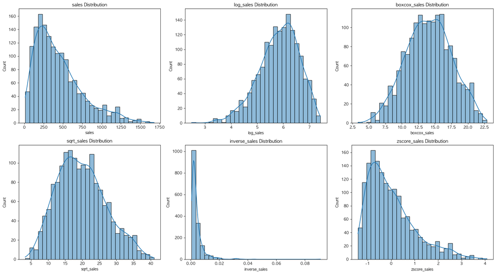

```
### Box-Cox 변환 데이터 선택 (Target Variable: boxcox_sales) ###

### 정규화된 수치형 변수 ###
       dwpt      prcp      pres      rhum      temp      wspd
0 -0.140691 -0.253049 -0.235556 -0.432226  0.026244  0.253595
1  0.320755 -0.253049 -0.391721  0.576418 -0.116094 -0.056080
2  0.787123 -0.253049 -0.740650  1.417856 -0.059159 -0.339060
3 -0.113620 -0.253049 -0.245317 -0.385506  0.021068  0.486742
4  0.341674 -0.253049 -0.412461  0.642317 -0.135504 -0.038283
```

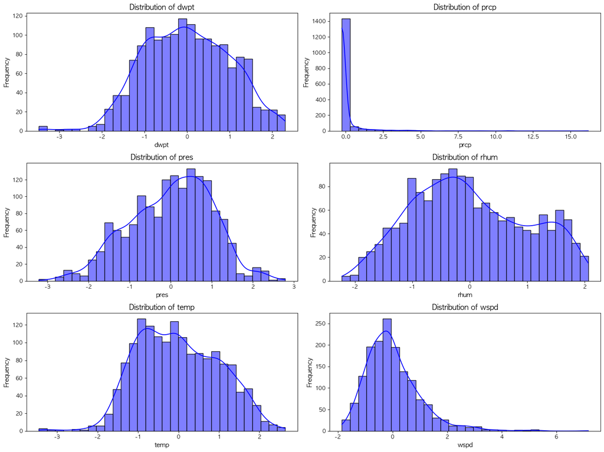

```
### Variance Inflation Factor (VIF) ###
                           Feature         VIF
0                            const  328.562594
1                             temp   43.213537
2                             dwpt   56.370201
3                             rhum   28.067784
4                             prcp    1.858221
5                             wspd    1.194428
6                             pres    1.295214
7    store_location_Hell's Kitchen    1.365982
8   store_location_Lower Manhattan    1.437920
9                   time_of_day_저녁    1.831381
10                  time_of_day_점심    1.444692
11         weather_group_주로 격렬한 날씨    1.611137
12              weather_group_주로 눈    3.209623
13             weather_group_주로 맑음   45.274383
14              weather_group_주로 비   23.205590
15             weather_group_주로 흐림   25.524004
16                   is_weekend_평일    1.036280
```

```python
# import pandas as pd
# import numpy as np
# import seaborn as sns
# import matplotlib.pyplot as plt
# from scipy.stats import shapiro, boxcox, probplot, kstest
# from statsmodels.stats.diagnostic import het_breuschpagan
# from statsmodels.api import OLS, add_constant
# from statsmodels.stats.outliers_influence import variance_inflation_factor
# from sklearn.model_selection import train_test_split

# 가설검정 혹은 데이터 탐색에는 필요 했을 수 있지만, 모델 생성에는 불필요한(혹은 중복) 변수 한번 더 체크하고 지워주기
data = final_result.drop(columns=['month', 'transaction_qty', 'transaction_date'])
temp = data

# 2. weekday를 평일과 주말로 나누기
data['is_weekend'] = data['weekday'].apply(lambda x: '주말' if x in ['Saturday', 'Sunday'] else '평일')
data = data.drop(columns=['weekday'])

# 4. 로그, Box-Cox, sqrt 변환 및 추가 변환 시도
data['log_sales'] = data['sales'].apply(lambda x: np.log1p(x))  # 로그 변환
data['boxcox_sales'], lambda_bc = boxcox(data['sales'])  # Box-Cox 변환
data['sqrt_sales'] = data['sales'].apply(np.sqrt)  # 제곱근 변환
data['inverse_sales'] = data['sales'].apply(lambda x: 1 / x if x != 0 else 0)  # 역수 변환
data['zscore_sales'] = (data['sales'] - data['sales'].mean()) / data['sales'].std()  # Z-Score 정규화

# 5. 정규성 검정 (Shapiro-Wilk 테스트)
stat_results = {}
for col in ['sales', 'log_sales', 'boxcox_sales', 'sqrt_sales', 'inverse_sales', 'zscore_sales']:
    stat, p_value = shapiro(data[col])
    stat_results[col] = (stat, p_value)
    print(f"{col}: Statistic={stat:.4f}, P-value={p_value:.4f}")

# 정규성 시각화
plt.figure(figsize=(18, 10))
for i, col in enumerate(['sales', 'log_sales', 'boxcox_sales', 'sqrt_sales', 'inverse_sales', 'zscore_sales'], 1):
    plt.subplot(2, 3, i)
    sns.histplot(data[col], kde=True, bins=30)
    plt.title(f"{col} Distribution")
plt.tight_layout()
plt.show()

# 선택된 예측 변수
target_variable = 'boxcox_sales'
print(f"\n### Box-Cox 변환 데이터 선택 (Target Variable: {target_variable}) ###")
data = data.drop(columns=['sales', 'log_sales', 'sqrt_sales', 'inverse_sales', 'zscore_sales'])

# 6. 범주형 변수 처리
categorical_columns = ['store_location', 'time_of_day', 'weather_group', 'is_weekend']
data_encoded = pd.get_dummies(data, columns=categorical_columns, drop_first=True)

# 7. 수치형 독립 변수 정규화
numerical_columns = data_encoded.select_dtypes(include=['float64', 'int64']).columns.difference([target_variable])

# z-score 정규화
for col in numerical_columns:
    data_encoded[col] = (data_encoded[col] - data_encoded[col].mean()) / data_encoded[col].std()

# # 로그 변환 정규화
# for col in numerical_columns:
#     data_encoded[col] = data_encoded[col].apply(lambda x: np.log1p(x) if x > 0 else 0)

print("\n### 정규화된 수치형 변수 ###")
print(data_encoded[numerical_columns].head())

# 6가지 변수 리스트
variables = ['dwpt', 'prcp', 'pres', 'rhum', 'temp', 'wspd']

# 분포 시각화
plt.figure(figsize=(16, 12))
for i, var in enumerate(variables, 1):
    plt.subplot(3, 2, i)
    sns.histplot(data_encoded[var], kde=True, bins=30, color='blue')
    plt.title(f"Distribution of {var}", fontsize=14)
    plt.xlabel(var, fontsize=12)
    plt.ylabel("Frequency", fontsize=12)
plt.tight_layout()
plt.show()

# 8. 다중공선성 확인 (VIF 계산)
X = add_constant(data_encoded.drop(columns=[target_variable]))
vif_data = pd.DataFrame()
vif_data["Feature"] = X.columns
vif_data["VIF"] = [variance_inflation_factor(X.values, i) for i in range(X.shape[1])]

print("\n### Variance Inflation Factor (VIF) ###")
print(vif_data)
```

```python
#vif 결과값에 의한 변수 제거

# 'dwpt', 'rhum' 열 제거 및 'weather_group_'으로 시작하는 열 제거
columns_to_drop = ['dwpt', 'rhum'] + [col for col in data_encoded.columns if col.startswith('weather_group_')]
data_encoded = data_encoded.drop(columns=columns_to_drop)

# 8. 다중공선성 확인 (VIF 계산)
X = add_constant(data_encoded.drop(columns=[target_variable]))
vif_data = pd.DataFrame()
vif_data["Feature"] = X.columns
vif_data["VIF"] = [variance_inflation_factor(X.values, i) for i in range(X.shape[1])]

print("\n### Variance Inflation Factor (VIF) ###")
print(vif_data)
```

```
### Variance Inflation Factor (VIF) ###
                          Feature       VIF
0                           const  8.469386
1                            temp  1.218133
2                            prcp  1.093033
3                            wspd  1.152653
4                            pres  1.151371
5   store_location_Hell's Kitchen  1.365108
6  store_location_Lower Manhattan  1.382774
7                  time_of_day_저녁  1.582616
8                  time_of_day_점심  1.410724
9                   is_weekend_평일  1.029913
```

## Target변수는 sales 이므로 회귀 문제

## 4.1 첫번째 모델 선태: 선형회귀모델

```python
data = data_encoded
```

### 4.1.a

```python
# import pandas as pd
# from sklearn.model_selection import train_test_split
# from sklearn.linear_model import LinearRegression
# from sklearn.metrics import mean_squared_error, r2_score
# import matplotlib.pyplot as plt

# 데이터를 train, test로 분할
train_data, test_data = train_test_split(data, test_size=0.3, random_state=42)

# train_data에서 X와 y 분리
X_train = train_data.drop(columns=["boxcox_sales"])  # 대상 변수 제거
y_train = train_data["boxcox_sales"]

# test_data에서 X와 y 분리
X_test = test_data.drop(columns=["boxcox_sales"])
y_test = test_data["boxcox_sales"]

# 선형 회귀 모델 초기화
linear_model = LinearRegression()

# 모델 학습
linear_model.fit(X_train, y_train)

# 테스트 데이터로 예측
y_test_pred = linear_model.predict(X_test)

# 모델 성능 평가
mse = mean_squared_error(y_test, y_test_pred)
r2 = r2_score(y_test, y_test_pred)

# 결과 출력
print("Linear Regression Performance:")
print(f"Mean Squared Error (MSE): {mse:.2f}")
print(f"R-squared (R²): {r2:.2f}")
```

```
Linear Regression Performance:
Mean Squared Error (MSE): 4.80
R-squared (R²): 0.60
```

```
=== Variable Impact on Sales ===
- If temp increases by 1 unit, sales are expected to increase by 1.09 units.
- If pres increases by 1 unit, sales are expected to increase by 0.08 units.
- If wspd increases by 1 unit, sales are expected to increase by 0.03 units.
- If prcp increases by 1 unit, sales are expected to decrease by 0.12 units.
- If is_weekend_평일 increases by 1 unit, sales are expected to decrease by 0.14 units.
- If store_location_Hell's Kitchen increases by 1 unit, sales are expected to decrease by 0.49 units.
- If store_location_Lower Manhattan increases by 1 unit, sales are expected to decrease by 1.13 units.
- If time_of_day_점심 increases by 1 unit, sales are expected to decrease by 2.13 units.
- If time_of_day_저녁 increases by 1 unit, sales are expected to decrease by 6.48 units.
```

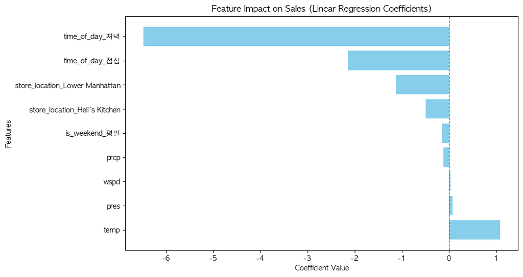

```python
# 1. 변수별 회귀 계수 추출
coefficients = linear_model.coef_
feature_names = X_train.columns

# 각 변수의 영향 계산
influence = pd.DataFrame({
    "Feature": feature_names,
    "Coefficient": coefficients
}).sort_values(by="Coefficient", ascending=False)

print("\n=== Variable Impact on Sales ===")
for index, row in influence.iterrows():
    effect = "increase" if row["Coefficient"] > 0 else "decrease"
    print(f"- If {row['Feature']} increases by 1 unit, sales are expected to {effect} by {abs(row['Coefficient']):.2f} units.")

# 2. 변수 영향 시각화 (전체 변수)
plt.figure(figsize=(10, 6))
plt.barh(influence["Feature"], influence["Coefficient"], color="skyblue")
plt.axvline(0, color="red", linestyle="--", linewidth=1)
plt.title("Feature Impact on Sales (Linear Regression Coefficients)")
plt.xlabel("Coefficient Value")
plt.ylabel("Features")
plt.show()
```

- time_of_day: 아침 기준. 점심은 아침보다 매출이 2.13 단위 감소. 저녁은 아침보다 매출이 6.48 단위 감소.
- store_location: Astoria 기준. Hell's Kitchen은 Astoria보다 매출이 0.49 단위 감소. Lower Manhattan은 Astoria보다 매출이 1.13 단위 감소.
- is_weekend: 주말 기준. 평일은 주말보다 매출이 0.14 단위 감소.

### 4.1.b 교차 검증/하이퍼파라미터 추가

```python
# from sklearn.model_selection import cross_val_score, KFold
# from sklearn.linear_model import Ridge
# from sklearn.preprocessing import StandardScaler
# from sklearn.pipeline import Pipeline
# import numpy as np

# 데이터를 train, test로 분할
train_data, test_data = train_test_split(data, test_size=0.3, random_state=42)

# Train 데이터를 X와 y로 분리
X_train = train_data.drop(columns=["boxcox_sales"])
y_train = train_data["boxcox_sales"]

# 교차 검증을 위한 설정
kfold = KFold(n_splits=5, shuffle=True, random_state=42)

# 1. 데이터 정규화와 선형 회귀 모델을 파이프라인으로 연결
pipeline = Pipeline([
    ("scaler", StandardScaler()),  # 특징 정규화
    ("linear_model", LinearRegression())  # 선형 회귀
])

# 교차 검증 실행
cv_scores = cross_val_score(pipeline, X_train, y_train, cv=kfold, scoring='r2')

print("Linear Regression with Cross-Validation:")
print(f"R-squared scores (per fold): {cv_scores}")
print(f"Mean R-squared: {np.mean(cv_scores):.2f}")

# 2. 정규화와 릿지 회귀 (하이퍼파라미터 알파 최적화 포함)
alphas = [0.01, 0.1, 1, 10, 100]
ridge_results = []

for alpha in alphas:
    ridge_pipeline = Pipeline([
        ("scaler", StandardScaler()),
        ("ridge_model", Ridge(alpha=alpha))  # 릿지 회귀
    ])
    ridge_scores = cross_val_score(ridge_pipeline, X_train, y_train, cv=kfold, scoring='r2')
    ridge_results.append((alpha, np.mean(ridge_scores)))

print("\nRidge Regression Results:")
for alpha, score in ridge_results:
    print(f"Alpha: {alpha}, Mean R-squared: {score:.2f}")

# 최적 alpha 선택
best_alpha, best_r2 = max(ridge_results, key=lambda x: x[1])
print(f"\nBest Alpha: {best_alpha}, Best R-squared: {best_r2:.2f}")

# 최적의 Ridge 모델로 학습 및 예측
final_ridge_pipeline = Pipeline([
    ("scaler", StandardScaler()),
    ("ridge_model", Ridge(alpha=best_alpha))
])

final_ridge_pipeline.fit(X_train, y_train)
X_test = test_data.drop(columns=["boxcox_sales"])
y_test = test_data["boxcox_sales"]

y_test_pred_ridge = final_ridge_pipeline.predict(X_test)
mse_ridge = mean_squared_error(y_test, y_test_pred_ridge)
r2_ridge = r2_score(y_test, y_test_pred_ridge)

print("\nFinal Ridge Regression Performance on Test Data:")
print(f"Mean Squared Error (MSE): {mse_ridge:.2f}")
print(f"R-squared (R²): {r2_ridge:.2f}")
```

```
Linear Regression with Cross-Validation:
R-squared scores (per fold): [0.60717095 0.59461278 0.53637418 0.60612025 0.61375182]
Mean R-squared: 0.59

Ridge Regression Results:
Alpha: 0.01, Mean R-squared: 0.59
Alpha: 0.1, Mean R-squared: 0.59
Alpha: 1, Mean R-squared: 0.59
Alpha: 10, Mean R-squared: 0.59
Alpha: 100, Mean R-squared: 0.57

Best Alpha: 1, Best R-squared: 0.59

Final Ridge Regression Performance on Test Data:
Mean Squared Error (MSE): 4.80
R-squared (R²): 0.60
```

```
=== Variable Impact on Sales ===
- If temp increases by 1 unit, sales are expected to increase by 1.08 units.
- If pres increases by 1 unit, sales are expected to increase by 0.07 units.
- If wspd increases by 1 unit, sales are expected to increase by 0.03 units.
- If is_weekend_평일 increases by 1 unit, sales are expected to decrease by 0.06 units.
- If prcp increases by 1 unit, sales are expected to decrease by 0.12 units.
- If store_location_Hell's Kitchen increases by 1 unit, sales are expected to decrease by 0.24 units.
- If store_location_Lower Manhattan increases by 1 unit, sales are expected to decrease by 0.53 units.
- If time_of_day_점심 increases by 1 unit, sales are expected to decrease by 1.00 units.
- If time_of_day_저녁 increases by 1 unit, sales are expected to decrease by 3.08 units.
```

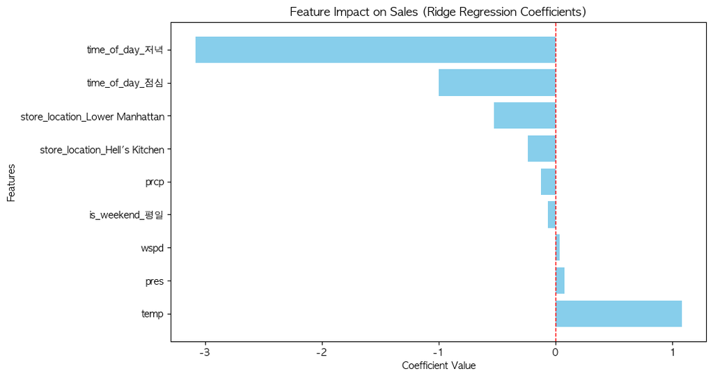

```python
# import matplotlib.pyplot as plt
# import pandas as pd
# import numpy as np

# Ridge 모델 학습 완료 후, 회귀 계수 추출
ridge_model = final_ridge_pipeline.named_steps["ridge_model"]
scaler = final_ridge_pipeline.named_steps["scaler"]
X_train_scaled = scaler.transform(X_train)

# Ridge 회귀 계수 및 변수 이름
coefficients = ridge_model.coef_
feature_names = X_train.columns

# 변수별 영향도 데이터프레임 생성
influence = pd.DataFrame({
    "Feature": feature_names,
    "Coefficient": coefficients
}).sort_values(by="Coefficient", ascending=False)

print("\n=== Variable Impact on Sales ===")
for index, row in influence.iterrows():
    effect = "increase" if row["Coefficient"] > 0 else "decrease"
    print(f"- If {row['Feature']} increases by 1 unit, sales are expected to {effect} by {abs(row['Coefficient']):.2f} units.")

# 변수 영향 시각화
plt.figure(figsize=(10, 6))
plt.barh(influence["Feature"], influence["Coefficient"], color='skyblue')
plt.axvline(0, color="red", linestyle="--", linewidth=1)
plt.title("Feature Impact on Sales (Ridge Regression Coefficients)")
plt.xlabel("Coefficient Value")
plt.ylabel("Features")
plt.show()
```

### 교차 검증과 튜닝을 통해 r^2 값은(모델의 설명도)는 미세한 차이가 생기지만 평균값은 결국 같음.

### 변수와 예측변수의 상관계수도 변하는 있지만 중요도의 차이는 변화 없음.

### 4.1.c 다른 교차 검정/튜닝

```python
# from sklearn.model_selection import GridSearchCV, KFold, ShuffleSplit
# from sklearn.linear_model import Ridge
# from sklearn.preprocessing import StandardScaler
# from sklearn.pipeline import Pipeline
# import numpy as np

# 데이터를 train, test로 분할
train_data, test_data = train_test_split(data, test_size=0.3, random_state=42)

X_train = train_data.drop(columns=["boxcox_sales"])
y_train = train_data["boxcox_sales"]

# 1. 하이퍼파라미터 튜닝: Grid Search + KFold
param_grid = {
    "ridge_model__alpha": [0.01, 0.1, 1, 10, 100, 200],  # alpha 탐색 범위
    "ridge_model__fit_intercept": [True, False],  # 절편 포함 여부
    "ridge_model__solver": ["auto", "svd", "cholesky", "lsqr", "sparse_cg"]  # 해법 선택
}

ridge_pipeline = Pipeline([
    ("scaler", StandardScaler()),  # 데이터 정규화
    ("ridge_model", Ridge())
])

grid_search = GridSearchCV(
    estimator=ridge_pipeline,
    param_grid=param_grid,
    scoring="r2",
    cv=KFold(n_splits=5, shuffle=True, random_state=42),  # KFold 교차 검증
    n_jobs=-1,  # 병렬 처리
    verbose=1
)

# Grid Search 실행
grid_search.fit(X_train, y_train)

# 최적 하이퍼파라미터 및 성능 출력
print("\nBest Parameters from Grid Search:")
print(grid_search.best_params_)
print(f"Best Cross-Validation R²: {grid_search.best_score_:.2f}")

# 2. ShuffleSplit을 사용한 교차 검증 비교
shuffle_split = ShuffleSplit(n_splits=5, test_size=0.2, random_state=42)
shuffle_scores = cross_val_score(grid_search.best_estimator_, X_train, y_train, cv=shuffle_split, scoring="r2")

print("\nShuffleSplit Cross-Validation Results:")
print(f"R-squared scores (per split): {shuffle_scores}")
print(f"Mean R-squared: {np.mean(shuffle_scores):.2f}")

# 3. 최종 모델 평가 (Test Set)
X_test = test_data.drop(columns=["boxcox_sales"])
y_test = test_data["boxcox_sales"]

final_model = grid_search.best_estimator_
y_test_pred = final_model.predict(X_test)

mse_test = mean_squared_error(y_test, y_test_pred)
r2_test = r2_score(y_test, y_test_pred)

print("\nFinal Ridge Model Performance on Test Data:")
print(f"Mean Squared Error (MSE): {mse_test:.2f}")
print(f"R-squared (R²): {r2_test:.2f}")
```

```
Fitting 5 folds for each of 60 candidates, totalling 300 fits

Best Parameters from Grid Search:
{'ridge_model__alpha': 1, 'ridge_model__fit_intercept': True, 'ridge_model__solver': 'sparse_cg'}
Best Cross-Validation R²: 0.59

ShuffleSplit Cross-Validation Results:
R-squared scores (per split): [0.60732646 0.58189435 0.59238357 0.58927243 0.60618961]
Mean R-squared: 0.60

Final Ridge Model Performance on Test Data:
Mean Squared Error (MSE): 4.80
R-squared (R²): 0.60
```

#### 교차검증/하이퍼파라미터 수정 후 R-squared/MSE 값 같음

```
=== Variable Impact on Sales ===
- If temp increases by 1 unit, sales are expected to increase by 1.08 units.
- If pres increases by 1 unit, sales are expected to increase by 0.08 units.
- If wspd increases by 1 unit, sales are expected to increase by 0.03 units.
- If is_weekend_평일 increases by 1 unit, sales are expected to decrease by 0.06 units.
- If prcp increases by 1 unit, sales are expected to decrease by 0.12 units.
- If store_location_Hell's Kitchen increases by 1 unit, sales are expected to decrease by 0.23 units.
- If store_location_Lower Manhattan increases by 1 unit, sales are expected to decrease by 0.53 units.
- If time_of_day_점심 increases by 1 unit, sales are expected to decrease by 1.00 units.
- If time_of_day_저녁 increases by 1 unit, sales are expected to decrease by 3.08 units.
```

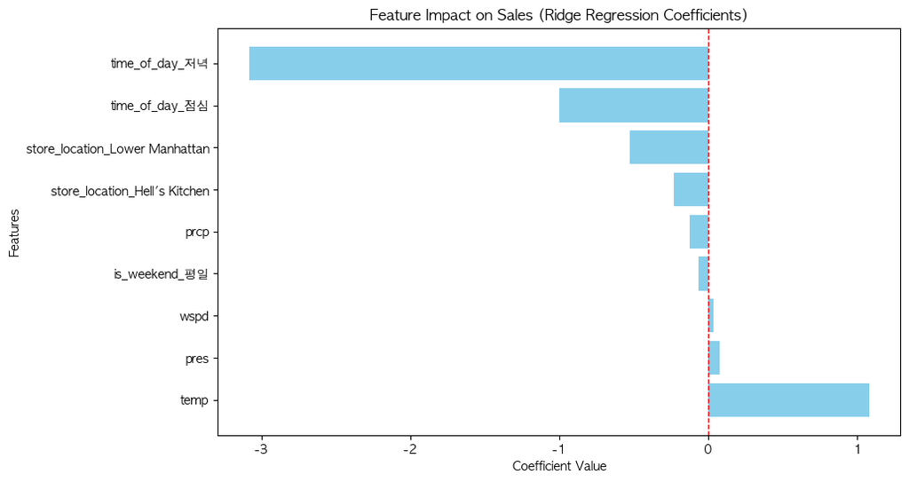

```python
# import matplotlib.pyplot as plt
# import pandas as pd
# import numpy as np

# Ridge 모델 학습 완료 후, 최적 모델의 회귀 계수 추출
final_ridge_model = final_model.named_steps["ridge_model"]
scaler = final_model.named_steps["scaler"]

# 데이터 정규화 후 회귀 계수 추출
X_train_scaled = scaler.transform(X_train)
coefficients = final_ridge_model.coef_
feature_names = X_train.columns

# 변수별 영향도 데이터프레임 생성
influence = pd.DataFrame({
    "Feature": feature_names,
    "Coefficient": coefficients
}).sort_values(by="Coefficient", ascending=False)

print("\n=== Variable Impact on Sales ===")
for index, row in influence.iterrows():
    effect = "increase" if row["Coefficient"] > 0 else "decrease"
    print(f"- If {row['Feature']} increases by 1 unit, sales are expected to {effect} by {abs(row['Coefficient']):.2f} units.")

# 변수 영향 시각화
plt.figure(figsize=(10, 6))
plt.barh(influence["Feature"], influence["Coefficient"], color="skyblue")
plt.axvline(0, color="red", linestyle="--", linewidth=1)
plt.title("Feature Impact on Sales (Ridge Regression Coefficients)")
plt.xlabel("Coefficient Value")
plt.ylabel("Features")
plt.show()
```

### 마찬가지. 설명도와 상관계수는 미세한 차이가 있을뿐 바뀌지 않았음.

## 4.2 두번째 모델: 랜덤 포레스트

### 4.2.a 기본 모델

```
Random Forest Model Performance on Test Data:
Mean Squared Error (MSE): 4.12
R-squared (R²): 0.66

=== Feature Importance (Random Forest) ===
                          Feature  Importance
6                  time_of_day_저녁    0.444711
0                            temp    0.205198
3                            pres    0.106529
2                            wspd    0.081771
5  store_location_Lower Manhattan    0.064466
7                  time_of_day_점심    0.055227
1                            prcp    0.019115
4   store_location_Hell's Kitchen    0.014483
8                   is_weekend_평일    0.008500
```

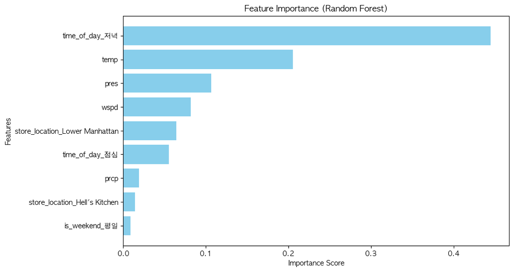

[figure not shown]

```python
# from sklearn.ensemble import RandomForestRegressor
# from sklearn.metrics import mean_squared_error, r2_score
# import matplotlib.pyplot as plt
# import numpy as np
# import pandas as pd

# 데이터를 train, test로 분할
train_data, test_data = train_test_split(data, test_size=0.3, random_state=42)

X_train = train_data.drop(columns=["boxcox_sales"])
y_train = train_data["boxcox_sales"]
X_test = test_data.drop(columns=["boxcox_sales"])
y_test = test_data["boxcox_sales"]

# 랜덤 포레스트 모델 초기화
rf_model = RandomForestRegressor(n_estimators=100, random_state=42)

# 모델 학습
rf_model.fit(X_train, y_train)

# 테스트 데이터로 예측
y_test_pred_rf = rf_model.predict(X_test)

# 모델 성능 평가
mse_rf = mean_squared_error(y_test, y_test_pred_rf)
r2_rf = r2_score(y_test, y_test_pred_rf)

print("\nRandom Forest Model Performance on Test Data:")
print(f"Mean Squared Error (MSE): {mse_rf:.2f}")
print(f"R-squared (R²): {r2_rf:.2f}")

# 변수 중요도 분석
feature_importances = rf_model.feature_importances_
feature_names = X_train.columns

# 변수 중요도를 데이터프레임으로 정리
importance_df = pd.DataFrame({
    "Feature": feature_names,
    "Importance": feature_importances
}).sort_values(by="Importance", ascending=False)

print("\n=== Feature Importance (Random Forest) ===")
print(importance_df)

# 변수 중요도 시각화
plt.figure(figsize=(10, 6))
plt.barh(importance_df["Feature"], importance_df["Importance"], color="skyblue")
plt.title("Feature Importance (Random Forest)")
plt.xlabel("Importance Score")
plt.ylabel("Features")
plt.gca().invert_yaxis()
plt.show()

# 3. 잔차 분석
residuals = y_test - y_test_pred_rf

plt.figure(figsize=(10, 6))
plt.scatter(y_test, residuals, alpha=0.5)
plt.axhline(0, color='red', linestyle='--', linewidth=1)
plt.title("Residuals Analysis (XGBoost)")
plt.xlabel("Actual Values")
plt.ylabel("Residuals")
plt.show()
```

### 4.2.b 교차검증/하이퍼파라미터

```
Starting Grid Search...
Fitting 5 folds for each of 324 candidates, totalling 1620 fits

Best Parameters from Grid Search:
{'max_depth': 10, 'max_features': None, 'min_samples_leaf': 1, 'min_samples_split': 5, 'n_estimators': 200}

Final Random Forest Model Performance on Test Data:
Mean Squared Error (MSE): 4.06
R-squared (R²): 0.67

=== Feature Importance (Optimized Random Forest) ===
                          Feature  Importance
6                  time_of_day_저녁    0.488228
0                            temp    0.198287
3                            pres    0.091015
5  store_location_Lower Manhattan    0.065825
2                            wspd    0.063635
7                  time_of_day_점심    0.060202
1                            prcp    0.016278
4   store_location_Hell's Kitchen    0.010883
8                   is_weekend_평일    0.005647
```

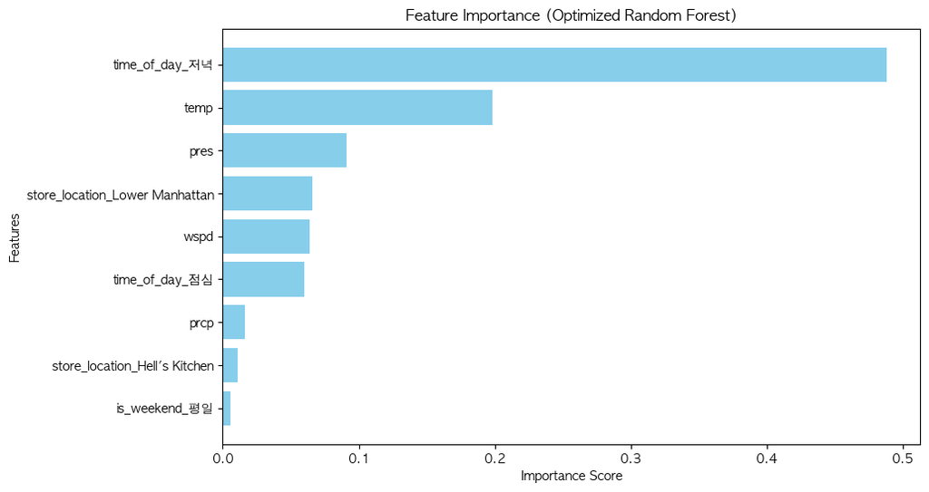

```
Cross-Validation Scores:
[0.67614782 0.69899124 0.61574635 0.69981077 0.66765066]
Mean R² from Cross-Validation: 0.67
```

[figure not shown]

```python
# from sklearn.model_selection import GridSearchCV, KFold
# from sklearn.ensemble import RandomForestRegressor
# from sklearn.metrics import mean_squared_error, r2_score
# import matplotlib.pyplot as plt
# import numpy as np
# import pandas as pd

# 데이터를 train, test로 분할
train_data, test_data = train_test_split(data, test_size=0.3, random_state=42)

X_train = train_data.drop(columns=["boxcox_sales"])
y_train = train_data["boxcox_sales"]
X_test = test_data.drop(columns=["boxcox_sales"])
y_test = test_data["boxcox_sales"]

# 1. 하이퍼파라미터 최적화 (Grid Search + KFold 교차검증)
param_grid = {
    "n_estimators": [50, 100, 200],  # 트리 개수
    "max_depth": [5, 10, 20, None],  # 최대 깊이
    "min_samples_split": [2, 5, 10],  # 노드 분할 최소 샘플 수
    "min_samples_leaf": [1, 2, 4],  # 리프 노드의 최소 샘플 수
    "max_features": ["sqrt", "log2", None]  # 최대 사용할 변수 수
}

rf_model = RandomForestRegressor(random_state=42)

grid_search = GridSearchCV(
    estimator=rf_model,
    param_grid=param_grid,
    scoring="r2",
    cv=KFold(n_splits=5, shuffle=True, random_state=42),
    n_jobs=-1,
    verbose=1
)

print("Starting Grid Search...")
grid_search.fit(X_train, y_train)

# 최적 하이퍼파라미터 출력
print("\nBest Parameters from Grid Search:")
print(grid_search.best_params_)

# 최적 모델로 테스트 데이터 예측
best_rf_model = grid_search.best_estimator_
y_test_pred_rf = best_rf_model.predict(X_test)

# 모델 성능 평가
mse_rf = mean_squared_error(y_test, y_test_pred_rf)
r2_rf = r2_score(y_test, y_test_pred_rf)

print("\nFinal Random Forest Model Performance on Test Data:")
print(f"Mean Squared Error (MSE): {mse_rf:.2f}")
print(f"R-squared (R²): {r2_rf:.2f}")

# 2. 변수 중요도 분석
feature_importances = best_rf_model.feature_importances_
feature_names = X_train.columns

# 변수 중요도 데이터프레임 생성
importance_df = pd.DataFrame({
    "Feature": feature_names,
    "Importance": feature_importances
}).sort_values(by="Importance", ascending=False)

print("\n=== Feature Importance (Optimized Random Forest) ===")
print(importance_df)

# 변수 중요도 시각화
plt.figure(figsize=(10, 6))
plt.barh(importance_df["Feature"], importance_df["Importance"], color="skyblue")
plt.title("Feature Importance (Optimized Random Forest)")
plt.xlabel("Importance Score")
plt.ylabel("Features")
plt.gca().invert_yaxis()
plt.show()

# 3. 교차 검증 성능 확인
from sklearn.model_selection import cross_val_score

cv_scores = cross_val_score(best_rf_model, X_train, y_train, cv=KFold(n_splits=5, shuffle=True, random_state=42), scoring="r2")
print("\nCross-Validation Scores:")
print(cv_scores)
print(f"Mean R² from Cross-Validation: {np.mean(cv_scores):.2f}")


# 3. 잔차 분석
residuals = y_test - y_test_pred_rf

plt.figure(figsize=(10, 6))
plt.scatter(y_test, residuals, alpha=0.5)
plt.axhline(0, color='red', linestyle='--', linewidth=1)
plt.title("Residuals Analysis (XGBoost)")
plt.xlabel("Actual Values")
plt.ylabel("Residuals")
plt.show()
```

r^2가 미세하게 증가해 일부 교차검증은 0.7까지 올라감.

### 4.2.c Grid Search + Repeated KFold 교차검증

```
Starting Grid Search...
Fitting 15 folds for each of 216 candidates, totalling 3240 fits

Best Parameters from Grid Search:
{'max_depth': 20, 'max_features': 'sqrt', 'min_samples_leaf': 1, 'min_samples_split': 4, 'n_estimators': 500}

Final Random Forest Model Performance on Test Data:
Mean Squared Error (MSE): 4.00
R-squared (R²): 0.67

=== Feature Importance (Optimized Random Forest) ===
                          Feature  Importance
6                  time_of_day_저녁    0.430100
0                            temp    0.188579
2                            wspd    0.129586
3                            pres    0.105130
5  store_location_Lower Manhattan    0.048995
7                  time_of_day_점심    0.047667
1                            prcp    0.025245
4   store_location_Hell's Kitchen    0.013027
8                   is_weekend_평일    0.011671
```

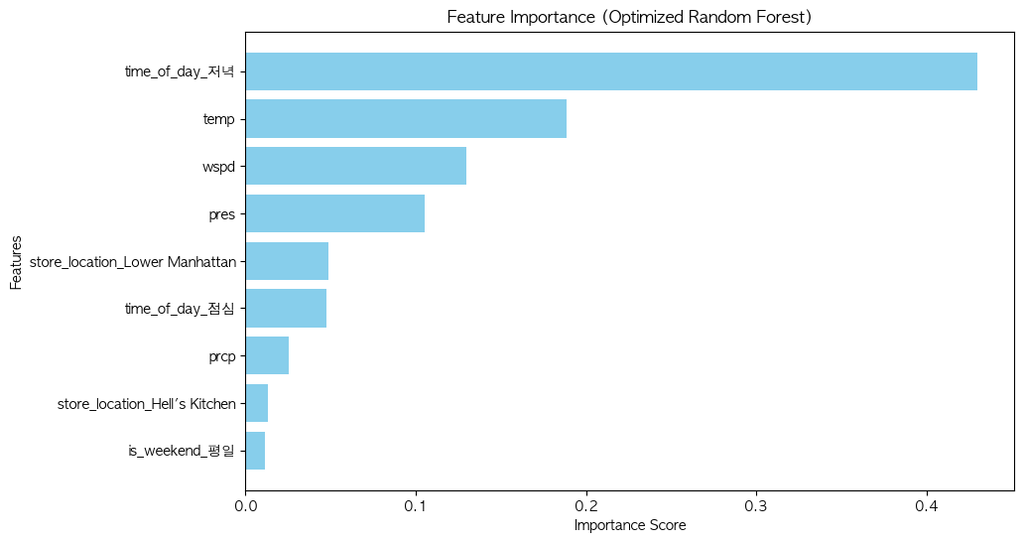

```
Cross-Validation Scores:
[0.69046575 0.68920459 0.60928035 0.6879875  0.68398643 0.66065104
 0.65582067 0.71101883 0.68822791 0.63308119 0.65907312 0.68541923
 0.69402881 0.68319184 0.632466  ]
Mean R² from Cross-Validation: 0.67
```

[figure not shown]

```python
# from sklearn.model_selection import GridSearchCV, KFold
# from sklearn.ensemble import RandomForestRegressor
# from sklearn.metrics import mean_squared_error, r2_score
# import matplotlib.pyplot as plt
# import numpy as np
# import pandas as pd

# 데이터를 train, test로 분할
train_data, test_data = train_test_split(data, test_size=0.3, random_state=42)

X_train = train_data.drop(columns=["boxcox_sales"])
y_train = train_data["boxcox_sales"]
X_test = test_data.drop(columns=["boxcox_sales"])
y_test = test_data["boxcox_sales"]

# 1. 하이퍼파라미터 최적화 (Grid Search + Repeated KFold 교차검증)
from sklearn.model_selection import RepeatedKFold

param_grid = {
    "n_estimators": [100, 300, 500],  # 트리 개수
    "max_depth": [10, 20, 30, None],  # 최대 깊이
    "min_samples_split": [2, 4, 6],  # 노드 분할 최소 샘플 수
    "min_samples_leaf": [1, 3, 5],  # 리프 노드의 최소 샘플 수
    "max_features": ["sqrt", "log2"]  # 최대 사용할 변수 수
}

rf_model = RandomForestRegressor(random_state=42)

# Repeated KFold 설정
rkf = RepeatedKFold(n_splits=5, n_repeats=3, random_state=42)

grid_search = GridSearchCV(
    estimator=rf_model,
    param_grid=param_grid,
    scoring="r2",
    cv=rkf,
    n_jobs=-1,
    verbose=1
)

print("Starting Grid Search...")
grid_search.fit(X_train, y_train)

# 최적 하이퍼파라미터 출력
print("\nBest Parameters from Grid Search:")
print(grid_search.best_params_)

# 최적 모델로 테스트 데이터 예측
best_rf_model = grid_search.best_estimator_
y_test_pred_rf = best_rf_model.predict(X_test)

# 모델 성능 평가
mse_rf = mean_squared_error(y_test, y_test_pred_rf)
r2_rf = r2_score(y_test, y_test_pred_rf)

print("\nFinal Random Forest Model Performance on Test Data:")
print(f"Mean Squared Error (MSE): {mse_rf:.2f}")
print(f"R-squared (R²): {r2_rf:.2f}")

# 2. 변수 중요도 분석
feature_importances = best_rf_model.feature_importances_
feature_names = X_train.columns

# 변수 중요도 데이터프레임 생성
importance_df = pd.DataFrame({
    "Feature": feature_names,
    "Importance": feature_importances
}).sort_values(by="Importance", ascending=False)

print("\n=== Feature Importance (Optimized Random Forest) ===")
print(importance_df)

# 변수 중요도 시각화
plt.figure(figsize=(10, 6))
plt.barh(importance_df["Feature"], importance_df["Importance"], color="skyblue")
plt.title("Feature Importance (Optimized Random Forest)")
plt.xlabel("Importance Score")
plt.ylabel("Features")
plt.gca().invert_yaxis()
plt.show()

# 3. 추가 시도: 교차 검증 성능 확인
from sklearn.model_selection import cross_val_score

cv_scores = cross_val_score(best_rf_model, X_train, y_train, cv=rkf, scoring="r2")
print("\nCross-Validation Scores:")
print(cv_scores)
print(f"Mean R² from Cross-Validation: {np.mean(cv_scores):.2f}")

# 3. 잔차 분석
residuals = y_test - y_test_pred_rf

plt.figure(figsize=(10, 6))
plt.scatter(y_test, residuals, alpha=0.5)
plt.axhline(0, color='red', linestyle='--', linewidth=1)
plt.title("Residuals Analysis (XGBoost)")
plt.xlabel("Actual Values")
plt.ylabel("Residuals")
plt.show()
```

### 여러 교차검증의 결과들이 전반적으로 선형회귀보다 높은 설명력을 가지고 있음

## 4.3 세번째 모델: XGBoost

### 4.3.a 교차 검증

```
Starting Grid Search...
Fitting 5 folds for each of 243 candidates, totalling 1215 fits

Best Parameters from Grid Search:
{'colsample_bytree': 1.0, 'learning_rate': 0.1, 'max_depth': 6, 'n_estimators': 50, 'subsample': 0.8}

Final XGBoost Model Performance on Test Data:
Mean Squared Error (MSE): 4.03
R-squared (R²): 0.67

=== Feature Importance (Optimized XGBoost) ===
                          Feature  Importance
6                  time_of_day_저녁    0.797377
7                  time_of_day_점심    0.075695
5  store_location_Lower Manhattan    0.062531
0                            temp    0.018393
3                            pres    0.011526
1                            prcp    0.010578
4   store_location_Hell's Kitchen    0.009662
2                            wspd    0.007998
8                   is_weekend_평일    0.006240
```

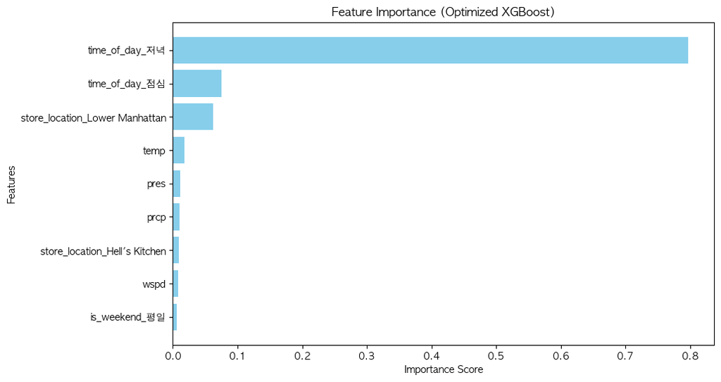

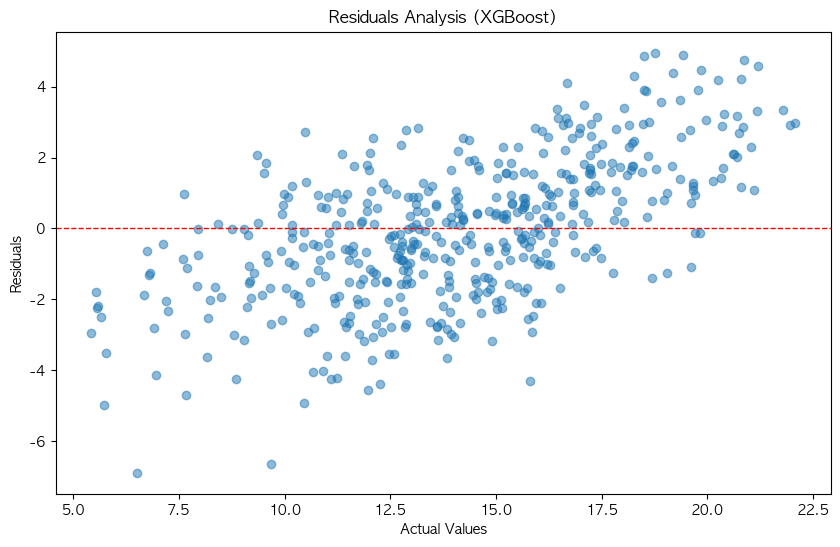

```python
# from sklearn.model_selection import train_test_split, GridSearchCV, KFold
# from sklearn.metrics import mean_squared_error, r2_score
# import matplotlib.pyplot as plt
# import numpy as np
# import pandas as pd
# import xgboost as xgb

# 데이터를 train, test로 분할
train_data, test_data = train_test_split(data, test_size=0.3, random_state=42)

X_train = train_data.drop(columns=["boxcox_sales"])
y_train = train_data["boxcox_sales"]
X_test = test_data.drop(columns=["boxcox_sales"])
y_test = test_data["boxcox_sales"]

# 1. 하이퍼파라미터 최적화 (Grid Search + KFold 교차검증)
param_grid = {
    "n_estimators": [50, 100, 200],  # 트리 개수
    "max_depth": [3, 6, 10],  # 최대 깊이
    "learning_rate": [0.01, 0.1, 0.2],  # 학습률
    "subsample": [0.6, 0.8, 1.0],  # 샘플링 비율
    "colsample_bytree": [0.6, 0.8, 1.0]  # 컬럼 샘플링 비율
}

xgb_model = xgb.XGBRegressor(random_state=42, objective='reg:squarederror')

grid_search = GridSearchCV(
    estimator=xgb_model,
    param_grid=param_grid,
    scoring="r2",
    cv=KFold(n_splits=5, shuffle=True, random_state=42),
    n_jobs=-1,
    verbose=1
)

print("Starting Grid Search...")
grid_search.fit(X_train, y_train)

# 최적 하이퍼파라미터 출력
print("\nBest Parameters from Grid Search:")
print(grid_search.best_params_)

# 최적 모델로 테스트 데이터 예측
best_xgb_model = grid_search.best_estimator_
y_test_pred_xgb = best_xgb_model.predict(X_test)

# 모델 성능 평가
mse_xgb = mean_squared_error(y_test, y_test_pred_xgb)
r2_xgb = r2_score(y_test, y_test_pred_xgb)

print("\nFinal XGBoost Model Performance on Test Data:")
print(f"Mean Squared Error (MSE): {mse_xgb:.2f}")
print(f"R-squared (R²): {r2_xgb:.2f}")

# 2. 변수 중요도 분석
feature_importances = best_xgb_model.feature_importances_
feature_names = X_train.columns

# 변수 중요도 데이터프레임 생성
importance_df = pd.DataFrame({
    "Feature": feature_names,
    "Importance": feature_importances
}).sort_values(by="Importance", ascending=False)

print("\n=== Feature Importance (Optimized XGBoost) ===")
print(importance_df)

# 변수 중요도 시각화
plt.figure(figsize=(10, 6))
plt.barh(importance_df["Feature"], importance_df["Importance"], color="skyblue")
plt.title("Feature Importance (Optimized XGBoost)")
plt.xlabel("Importance Score")
plt.ylabel("Features")
plt.gca().invert_yaxis()
plt.show()

# 3. 잔차 분석
residuals = y_test - y_test_pred_xgb

plt.figure(figsize=(10, 6))
plt.scatter(y_test, residuals, alpha=0.5)
plt.axhline(0, color='red', linestyle='--', linewidth=1)
plt.title("Residuals Analysis (XGBoost)")
plt.xlabel("Actual Values")
plt.ylabel("Residuals")
plt.show()
```

### 한 변수에 치우쳐 있는것을 확인. 가설 검정에서 추측한 결과와 조금 다른 방향.

## 4.3.b Grid Search + RepeatedKFold 교차검증 + 다른 파라미터

```
Starting Grid Search...
Fitting 10 folds for each of 108 candidates, totalling 1080 fits

Best Parameters from Grid Search:
{'colsample_bytree': 0.9, 'learning_rate': 0.05, 'max_depth': 4, 'n_estimators': 100, 'subsample': 0.9}

Final XGBoost Model Performance on Test Data:
Mean Squared Error (MSE): 4.09
R-squared (R²): 0.66

=== Feature Importance (Optimized XGBoost) ===
                          Feature  Importance
6                  time_of_day_저녁    0.691712
7                  time_of_day_점심    0.098662
5  store_location_Lower Manhattan    0.094963
0                            temp    0.041181
2                            wspd    0.018438
3                            pres    0.018060
1                            prcp    0.016725
4   store_location_Hell's Kitchen    0.014024
8                   is_weekend_평일    0.006236
```

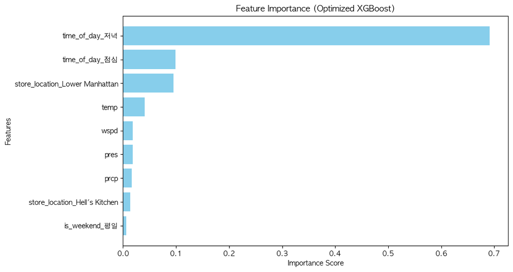

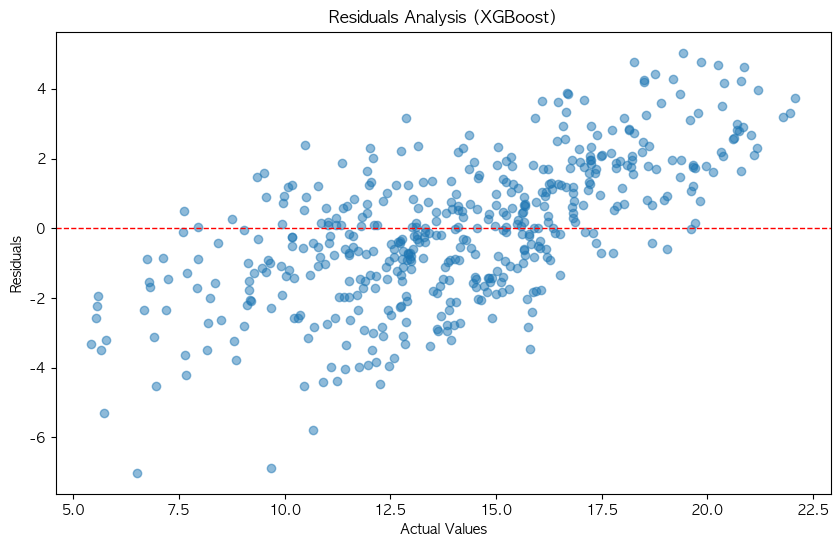

```python
# 데이터를 train, test로 분할
train_data, test_data = train_test_split(data, test_size=0.3, random_state=42)

X_train = train_data.drop(columns=["boxcox_sales"])
y_train = train_data["boxcox_sales"]
X_test = test_data.drop(columns=["boxcox_sales"])
y_test = test_data["boxcox_sales"]

# 1. 하이퍼파라미터 최적화 (Grid Search + RepeatedKFold 교차검증)
param_grid = {
    "n_estimators": [100, 300, 500],  # 트리 개수
    "max_depth": [4, 8, 12],  # 최대 깊이
    "learning_rate": [0.05, 0.1, 0.15],  # 학습률
    "subsample": [0.7, 0.9],  # 샘플링 비율
    "colsample_bytree": [0.7, 0.9]  # 컬럼 샘플링 비율
}

xgb_model = xgb.XGBRegressor(random_state=42, objective='reg:squarederror')

grid_search = GridSearchCV(
    estimator=xgb_model,
    param_grid=param_grid,
    scoring="r2",
    cv=RepeatedKFold(n_splits=5, n_repeats=2, random_state=42),
    n_jobs=-1,
    verbose=1
)

print("Starting Grid Search...")
grid_search.fit(X_train, y_train)

# 최적 하이퍼파라미터 출력
print("\nBest Parameters from Grid Search:")
print(grid_search.best_params_)

# 최적 모델로 테스트 데이터 예측
best_xgb_model = grid_search.best_estimator_
y_test_pred_xgb = best_xgb_model.predict(X_test)

# 모델 성능 평가
mse_xgb = mean_squared_error(y_test, y_test_pred_xgb)
r2_xgb = r2_score(y_test, y_test_pred_xgb)

print("\nFinal XGBoost Model Performance on Test Data:")
print(f"Mean Squared Error (MSE): {mse_xgb:.2f}")
print(f"R-squared (R²): {r2_xgb:.2f}")

# 2. 변수 중요도 분석
feature_importances = best_xgb_model.feature_importances_
feature_names = X_train.columns

# 변수 중요도 데이터프레임 생성
importance_df = pd.DataFrame({
    "Feature": feature_names,
    "Importance": feature_importances
}).sort_values(by="Importance", ascending=False)

print("\n=== Feature Importance (Optimized XGBoost) ===")
print(importance_df)

# 변수 중요도 시각화
plt.figure(figsize=(10, 6))
plt.barh(importance_df["Feature"], importance_df["Importance"], color="skyblue")
plt.title("Feature Importance (Optimized XGBoost)")
plt.xlabel("Importance Score")
plt.ylabel("Features")
plt.gca().invert_yaxis()
plt.show()

# 3. 잔차 분석
residuals = y_test - y_test_pred_xgb

plt.figure(figsize=(10, 6))
plt.scatter(y_test, residuals, alpha=0.5)
plt.axhline(0, color='red', linestyle='--', linewidth=1)
plt.title("Residuals Analysis (XGBoost)")
plt.xlabel("Actual Values")
plt.ylabel("Residuals")
plt.show()
```

### 이전 결과와 비슷함

```
Starting Grid Search...
Fitting 3 folds for each of 32 candidates, totalling 96 fits

Best Parameters from Grid Search:
{'colsample_bytree': 1.0, 'learning_rate': 0.05, 'max_depth': 4, 'n_estimators': 100, 'subsample': 0.8}

Final XGBoost Model Performance on Test Data:
Mean Squared Error (MSE): 4.07
R-squared (R²): 0.66

=== Feature Importance (Optimized XGBoost) ===
                          Feature  Importance
6                  time_of_day_저녁    0.708351
5  store_location_Lower Manhattan    0.108006
7                  time_of_day_점심    0.075092
0                            temp    0.038263
1                            prcp    0.018151
3                            pres    0.018127
4   store_location_Hell's Kitchen    0.015779
2                            wspd    0.011151
8                   is_weekend_평일    0.007082
```

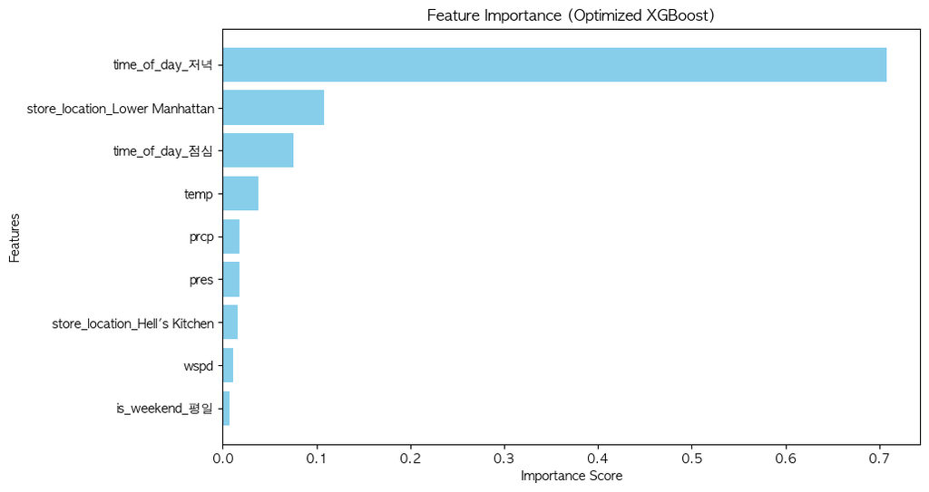

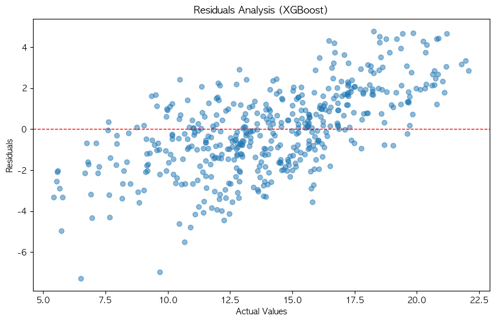

```python
# from sklearn.model_selection import train_test_split, GridSearchCV, KFold
# from sklearn.metrics import mean_squared_error, r2_score
# import matplotlib.pyplot as plt
# import numpy as np
# import pandas as pd
# import xgboost as xgb

# 데이터를 train, test로 분할
train_data, test_data = train_test_split(data, test_size=0.3, random_state=42)

X_train = train_data.drop(columns=["boxcox_sales"])
y_train = train_data["boxcox_sales"]
X_test = test_data.drop(columns=["boxcox_sales"])
y_test = test_data["boxcox_sales"]

# 1. 하이퍼파라미터 최적화 (Grid Search + KFold 교차검증)
param_grid = {
    "n_estimators": [100, 200],  # 트리 개수 축소
    "max_depth": [4, 8],  # 최대 깊이 축소
    "learning_rate": [0.05, 0.1],  # 학습률 축소
    "subsample": [0.8, 1.0],  # 샘플링 비율
    "colsample_bytree": [0.8, 1.0]  # 컬럼 샘플링 비율
}

xgb_model = xgb.XGBRegressor(random_state=42, objective='reg:squarederror')

grid_search = GridSearchCV(
    estimator=xgb_model,
    param_grid=param_grid,
    scoring="r2",
    cv=KFold(n_splits=3, shuffle=True, random_state=42),  # KFold로 변경
    n_jobs=-1,
    verbose=1
)

print("Starting Grid Search...")
grid_search.fit(X_train, y_train)

# 최적 하이퍼파라미터 출력
print("\nBest Parameters from Grid Search:")
print(grid_search.best_params_)

# 최적 모델로 테스트 데이터 예측
best_xgb_model = grid_search.best_estimator_
y_test_pred_xgb = best_xgb_model.predict(X_test)

# 모델 성능 평가
mse_xgb = mean_squared_error(y_test, y_test_pred_xgb)
r2_xgb = r2_score(y_test, y_test_pred_xgb)

print("\nFinal XGBoost Model Performance on Test Data:")
print(f"Mean Squared Error (MSE): {mse_xgb:.2f}")
print(f"R-squared (R²): {r2_xgb:.2f}")

# 2. 변수 중요도 분석
feature_importances = best_xgb_model.feature_importances_
feature_names = X_train.columns

# 변수 중요도 데이터프레임 생성
importance_df = pd.DataFrame({
    "Feature": feature_names,
    "Importance": feature_importances
}).sort_values(by="Importance", ascending=False)

print("\n=== Feature Importance (Optimized XGBoost) ===")
print(importance_df)

# 변수 중요도 시각화
plt.figure(figsize=(10, 6))
plt.barh(importance_df["Feature"], importance_df["Importance"], color="skyblue")
plt.title("Feature Importance (Optimized XGBoost)")
plt.xlabel("Importance Score")
plt.ylabel("Features")
plt.gca().invert_yaxis()
plt.show()

# 3. 잔차 분석
residuals = y_test - y_test_pred_xgb

plt.figure(figsize=(10, 6))
plt.scatter(y_test, residuals, alpha=0.5)
plt.axhline(0, color='red', linestyle='--', linewidth=1)
plt.title("Residuals Analysis (XGBoost)")
plt.xlabel("Actual Values")
plt.ylabel("Residuals")
plt.show()
```